# Tree management practices and outcomes

Cory Whitney

## Introduction

Forested areas occupy approximately 31% of the world’s land surface yet disproportionately contribute to global biodiversity, carbon sequestration, and provisioning services (Food and Agriculture Organization of the United Nations 2024; Vié, Hilton-Taylor, and Stuart 2009). Despite their critical ecological role, forests face extreme demands for products, with land conversion and agricultural expansion representing the most significant and detrimental pressures. The challenge is to improve management practices to benefit both the environment and communities without sacrificing economic and developmental needs.

A substantial portion of global forests are dedicated to production. Currently, 28% of forests are managed primarily for production, and another 18% for multiple uses, which can include intensive production, collectively representing nearly half of all forests with designated management objectives (Food and Agriculture Organization of the United Nations 2020). Furthermore, an estimated 70% of global forests show clear effects of human activity, classified as secondary or otherwise altered (Food and Agriculture Organization of the United Nations 2020, 2022). This presents a significant opportunity for adaptive management. Given that demand for wood products continues to rise, reaching 4 billion m³ annually (Food and Agriculture Organization of the United Nations 2024), and alternatives like agricultural fibers or mycelium composites face substantial barriers to large-scale adoption (Jones and al. 2020; Nietzel and al. 2022), sustainable wood production from these non-primary forests is crucial.

This work explores how traditional knowledge (TK) can be applied to enhance the sustainability and productivity of forest and tree management. A key application is in agroforestry—the integration of trees into human-managed landscapes—which is rooted in practices used for millennia by traditional cultures (Michon 2005). Many landscapes now considered “undisturbed” forest have, in reality, been shaped by historical human manipulation (Willis, Gillson, and Brncic 2004). Modern agroforestry systems, inspired by these practices, can provide a wide range of materials, potentially creating novel sources of woody biomass and alleviating pressure on primary forests.

Leveraging TK also serves to preserve this important knowledge base, which is often at risk of being lost. For instance, ethnobotanical studies have documented plant uses but frequently fail to capture the associated knowledge of cultivation and landscape integration (Kujawska and Luczaj 2015). Applying TK to manage secondary forests is particularly relevant. Since these forests already deviate from primary conditions, they offer flexibility for management interventions, such as pruning and thinning, which can enhance carbon sequestration and provide communities with fuel wood while increasing yield potential (Ameray et al. 2021). However, community management faces challenges, as even the harvest of non-timber forest products can have negative ecological impacts if not aligned with sustainable practices (Garcia-Fernandez, Casado, and Ruiz-Perez 2008). Therefore, integrating TK with scientific knowledge offers a pathway to foster healthier, more productive forests that support livelihoods while maintaining ecological function.

## Processing the papers

### Search Query

Search in Scopus within ‘Article Title, Abstract, Keywords’

( “ethnoforest*” OR “traditional ecological knowledge” ) + ( “tree” OR “forest” OR “agroforestry” OR “silviculture” ) + ( “effect” OR “development” OR “improvement” OR “potential” ) + ( “management” OR “use” )

Revealed 188 results

This analysis maps the scientific literature to answer two questions:

- What are the dominant themes in the broad literature on sustainable forest management? (Based on the large Scopus corpus).
- More specifically, what practices and outcomes are most associated with Traditional Knowledge and Ethnoforestry? (Based on the targeted TK corpus). This second question directly addresses the potential of TK outlined in the introduction.

```r
# Load BibTeX data
bib_data <- read.bib("refs/scopus.bib")
bib_keys <- sapply(bib_data, function(x) x$key)

# Extract text (title + abstract)
bib_df <- data.frame(
  key = bib_keys,
  text = sapply(bib_data, function(x) paste(x$title, x$abstract, x$keywords, sep = " "))
)
```

Preprocess the text corpus

```r
corpus <- VCorpus(VectorSource(bib_df$text))
corpus <- corpus %>%
  tm_map(content_transformer(tolower)) %>%
  tm_map(removePunctuation) %>%
  tm_map(removeNumbers) %>%
  tm_map(removeWords, stopwords("en")) %>%
  # stemming to reduce words to their base / root form
  tm_map(stemDocument) %>%  # Add stemming
  tm_map(stripWhitespace)
```

Check for dropped papers

```r
source("functions/log_dropped_docs.R")

corpus <- log_dropped_docs(corpus, content_transformer(tolower), "Convert to lowercase")
```

```
## No documents dropped after: Convert to lowercase
```

```r
corpus <- log_dropped_docs(corpus, removePunctuation, "Remove punctuation")
```

```
## No documents dropped after: Remove punctuation
```

```r
corpus <- log_dropped_docs(corpus, removeNumbers, "Remove numbers")
```

```
## No documents dropped after: Remove numbers
```

```r
# corpus <- log_dropped_docs(corpus, removeWords, stopwords("en"), "Remove stopwords")
corpus <- log_dropped_docs(corpus, stemDocument, "Apply stemming")
```

```
## No documents dropped after: Apply stemming
```

There were 7,876 returns in the Scopus search of Title, Abstract and Keywords: `( "agroforestry" OR "silviculture" OR "conservation forest" OR "community forest" ) + ( "effect" OR "development" OR "improvement" OR "potential" ) + ( "management" )`.

Compiling and remove duplicates and erroneous returns for a total of 7426 papers in search. Use these to create a Term-Document Matrix (TDM).

```r
#TDM
tdm <- TermDocumentMatrix(corpus)

# Convert TDM to a matrix
tdm_matrix <- as.matrix(tdm)
```

Create an inspection process for frequently occurring terms.

```r
# Inspect frequently occurring terms
term_freq <- rowSums(tdm_matrix)
term_freq_sorted <- sort(term_freq, decreasing = TRUE)
head(term_freq_sorted, 50)
```

```
##       forest        manag         tree         soil          use       system
##        24812        16508        12803        10532        10395         9698
##        speci agroforestri        studi       effect      product        stand
##         9428         8022         7926         7672         7137         6701
##       increa         area      develop       differ    communiti         land
##         6570         5848         5769         5384         5378         5233
##        chang       result        plant  silvicultur      practic        model
##         5183         5183         4787         4710         4699         4647
##       growth      sustain      potenti       carbon        natur         crop
##         4366         4307         4231         4057         4016         3966
##   agricultur    treatment         year      conserv          can       climat
##         3928         3920         3920         3888         3824         3716
##       signif        diver         site       improv    ecosystem        water
##         3547         3397         3396         3340         3309         3301
##      environ      harvest       impact     structur     research       import
##         3279         3182         3091         3091         3076         3073
##      plantat         high
##         3017         2980
```

Create an overview of the associations between tree management and relevant outcomes from the references.

```r
source("functions/workflow_for_each_paper.R")
# takes a while to run
```

Create an overview of practice keywords in the reference search.

```r
# Check keyword presence (check how often practices show up in the literature)
practice_check <- sapply(practices, function(practice) {
  sum(grepl(practice, text_data, ignore.case = TRUE))
})
print(practice_check)
```

```
##      Agroforestry Community_Forests      Silviculture     Urban_Forests
##              7385              1864              2499               239
##      Conservation
##                89
```

Overview the results of the outcome keywords in the reference search.

```r
# (check how often outcomes show up in the literature)
outcome_check <- sapply(outcomes, function(outcome) {
  sum(grepl(outcome, text_data, ignore.case = TRUE))
})
print(outcome_check)
```

```
##           Economic       Biodiversity             Carbon          Nutrition
##                 11               1236               1151                164
##        Livelihoods Ecosystem_Services
##                534               1904
```

Ready the reference data for a plot of associations.

```r
library(ggplot2)
library(stringr)

# Create human-readable labels by replacing underscores or capitalization patterns
association_df$PracticeGroup <- str_replace_all(association_df$PracticeGroup, "_", " ")
association_df$PracticeGroup <- str_to_title(association_df$PracticeGroup) # Convert to title case

association_df$OutcomeGroup <- str_replace_all(association_df$OutcomeGroup, "_", " ")
association_df$OutcomeGroup <- str_to_title(association_df$OutcomeGroup) # Convert to title case
```

Create an `OutcomeGroup` and check that the values match categories.

```r
# Define the outcome categories
human_development_outcomes <- c("Economic", "Livelihoods", "Nutrition")
biodiversity_outcomes <- c("Carbon", "Biodiversity", "Ecosystem Services")

# Add the classification column for outcomes
association_df$OutcomeCategory <- ifelse(
  association_df$OutcomeGroup %in% human_development_outcomes,
  "Human Development",
  ifelse(
    association_df$OutcomeGroup %in% biodiversity_outcomes,
    "Biodiversity",
    NA  # Assign NA if it doesn't match any category
  )
)

# Check for any NA values in OutcomeCategory
if (any(is.na(association_df$OutcomeCategory))) {
  warning("Some OutcomeGroup values did not match any category. Please review the data.")
}
```

## Associations in the Tree Management Practices Literature

Plot of the associations between tree management and outcomes for people and the environment.

```r
# Ensure proper ordering of x-axis labels grouped by category
all_outcomes <- c(human_development_outcomes, biodiversity_outcomes)

association_df$OutcomeGroup <- factor(
  association_df$OutcomeGroup,
  levels = all_outcomes
)
```

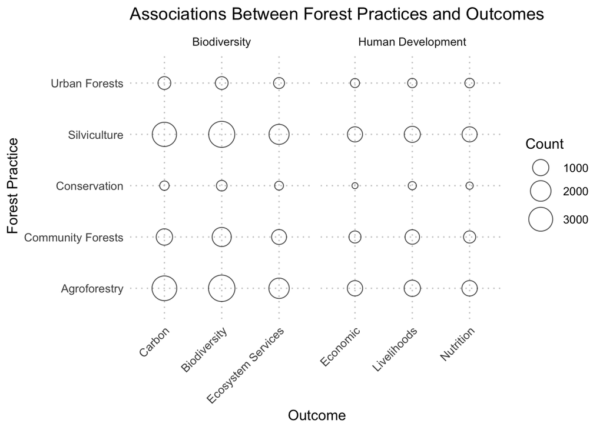

```r
# Bubble plot with grouped x-axis
association_plot <- ggplot(association_df, aes(x = OutcomeGroup, y = PracticeGroup, size = Count)) +
  geom_point(shape = 21, color = "black", alpha = 0.7) +
  scale_size_continuous(name = "Count", range = c(2, 10)) +
  labs(
    title = "Associations Between Forest Practices and Outcomes",
    x = "Outcome",
    y = "Forest Practice"
  ) +
  theme_minimal(base_size = 12) +
  theme(
    axis.text.x = element_text(angle = 45, hjust = 1),
    panel.grid.major = element_line(color = "gray80", linetype = "dotted"),
    panel.grid.minor = element_blank()
  ) +
  facet_grid(~ OutcomeCategory, scales = "free_x", space = "free")

association_plot
```

```r
ggsave(filename = "figures/association_plot.png", plot = association_plot, width = 8, height = 5, bg = "white")
```

## Overview of References

Get the references.

```r
source("functions/workflow_tkik_outcomes.R")
# takes a while to run
```

Create an overview of practice keywords in the reference search.

```r
# Check keyword presence (check how often practices show up in the literature)
tkik_practice_check <- sapply(tkik_practices, function(practice) {
  sum(grepl(practice, tkik_text_data, ignore.case = TRUE))
})
print(tkik_practice_check)
```

```
##         Ethnoforestry Traditional_Knowledge
##                    70                     3
```

```r
write_csv(tkik_association_df, "data/tkik_association_df.csv")
```

There were 16 citations related to Ethnoforestry and Economic ; they were Dossou-Yovo, Kindomihou, and Sinsin (2020), Hudson et al. (2020), Maezumi et al. (2018), Cotta (2017), Roshetko et al. (2017), Bost (2014), Pröpper and Vollan (2013), German et al. (2009), Gudeta W. Sileshi et al. (2009), Huang and Long (2007), D. N. Pandey (2002a), D. N. Pandey (2002b), Madge (1995), Gunatilleke, Gunatilleke, and Abeygunawardena (1993), Alcorn (1984), Miehe (1986) .

There were 46 citations related to Traditional_Knowledge and Economic ; they were Zoysa (2022), Hazarika et al. (2024), Zebrowski and Reynolds (2024), Silva-Galicia et al. (2023), Piabuo et al. (2022), Urruth, Bassi, and Chemello (2022), Lintangah et al. (2022), Ellis, Navarro-Martínez, and García-Ortega (2021), Tenagyei and Kanton Osumanu (2021), Deb (2020), Graziosi et al. (2020), Fitts, Cruz-Burga, and La Torre-Cuadros (2020), Neves and Heckenberger (2019), Scudder, Herbohn, and Baynes (2019), R. K. Singh et al. (2018), J. Wang and Meng (2018), Cotta (2017), Roshetko et al. (2017), Langston et al. (2017), Carias Vega and Keenan (2016), Sahide, Nurrochmat, and Giessen (2015), Mason et al. (2015), Negash et al. (2013), Fullen et al. (2011), Florencia Montagnini, Eibl, and Barth (2011), Focacci, Piussi, and Ciampi (2011), Steward and Beveridge (2010), Bray and Velázquez (2009), Burkhart and Jacobson (2009), Gudeta W. Sileshi et al. (2009), Diemont and Martin (2009), Nahuelhual et al. (2008), Ventura-Aquino et al. (2008), Elias and Carney (2007), Booth et al. (2007), Fullen et al. (2007), Teklehaimanot (2004), Adin et al. (2004), K. C. Paudel et al. (2003), Leakey (2001), Panda (1999), Long and Nair (1999), Fuchs (1996), Madge (1995), Rodan, Newton, and Verissimo (1992), Alcorn (1984) .

There were 43 citations related to Ethnoforestry and Biodiversity ; they were Rastogi et al. (2024), Rai and Singh (2024), Ghosal, Majumdar, and Ruj (2023), Bhandari, Pandeya, and Ghimire (2023), Fettig et al. (2023), Cadena-Zamudio et al. (2023), Zerbo et al. (2022), Ortega-Álvarez, Pacheco-Flores, and Casas (2022), Mariel et al. (2022), Mandila and Namaswa (2022), L. Hakim (2021), Nandigama (2020), Dossou-Yovo, Kindomihou, and Sinsin (2020), Hudson et al. (2020), Dhruba Bijaya et al. (2019), Lokonon et al. (2019), Wall et al. (2019), Sardeshpande and Shackleton (2019), Luchman Hakim et al. (2018), Maezumi et al. (2018), Nischalke et al. (2017), Cotta (2017), Moreno-Calles et al. (2016), Souza et al. (2016), Nath, Lal, and Das (2015), Gorel, Fayolle, and Doucet (2015), Munoz et al. (2014), Van Itterbeeck et al. (2014), Meunier et al. (2014), Rai (2012), Reyes-García et al. (2011), Chesworth (2011), German et al. (2009), Zou, Dao, and Long (2009), Gudeta W. Sileshi et al. (2009), D. N. Pandey (2007), Huang and Long (2007), Svenning and Macía (2002), D. N. Pandey (2002a), D. N. Pandey (2002b), De Jong (1994), Gunatilleke, Gunatilleke, and Abeygunawardena (1993), Alcorn (1984) .

There were 16 citations related to Ethnoforestry and Carbon ; they were Rai and Singh (2024), Mariel et al. (2022), Mandila and Namaswa (2022), Dhruba Bijaya et al. (2019), Roshetko et al. (2017), Moreno-Calles et al. (2016), Nath, Lal, and Das (2015), Gorel, Fayolle, and Doucet (2015), German et al. (2009), Zou, Dao, and Long (2009), Gudeta W. Sileshi et al. (2009), Gudeta Weldesemayat Sileshi et al. (2008), D. N. Pandey (2007), D. N. Pandey (2002a), D. N. Pandey (2002b), Gunatilleke, Gunatilleke, and Abeygunawardena (1993) .

There were 21 citations related to Ethnoforestry and Nutrition ; they were Fettig et al. (2023), Cadena-Zamudio et al. (2023), Muhesi et al. (2023), Zerbo et al. (2022), Ortega-Álvarez, Pacheco-Flores, and Casas (2022), Sardeshpande and Shackleton (2019), Maezumi et al. (2018), Nischalke et al. (2017), Cotta (2017), Roshetko et al. (2017), Moreno-Calles et al. (2016), Van Itterbeeck et al. (2014), Bost (2014), Chesworth (2011), Gudeta W. Sileshi et al. (2009), D. N. Pandey (2007), Miller and Nair (2006), D. N. Pandey (2002a), D. N. Pandey (2002b), Alcorn (1984), Miehe (1986) .

There were 63 citations related to Traditional_Knowledge and Nutrition ; they were Akinkuolie et al. (2024), Rassing, Gunawan, and Pratiwi (2024), Degefu and Kifle (2024), Antonelli (2023), Pangapanga-Phiri et al. (2022), Ortega-Álvarez, Pacheco-Flores, and Casas (2022), Shinbrot et al. (2022), Lintangah et al. (2022), Gerson N. Njurumana et al. (2021), Gonçalves, Schlindwein, and Martinelli (2021), Meinhold and Darr (2021), Imoro et al. (2021), Bishaw (2021), Tenagyei and Kanton Osumanu (2021), Villa et al. (2020), Graziosi et al. (2020), Neves and Heckenberger (2019), Córdova, Hogarth, and Kanninen (2019), Tadesse et al. (2019), Middendorp, Vanacker, and Lambin (2018), Hanif et al. (2018), Vera, Cota-Sánchez, and Grijalva Olmedo (2017), Jacobi et al. (2017), Cotta (2017), Jusu and Cuni-Sanchez (2017), Roshetko et al. (2017), Xiu et al. (2017), Moreno-Calles et al. (2016), K. Z. Mganga, Musimba, and Nyariki (2015), Mason et al. (2015), Vihotogbé et al. (2014), Van Itterbeeck et al. (2014), Bonilla-Bedoya et al. (2013), Mesa and Galeano (2013), Martini et al. (2013), Lombardero, Alonso-Rodríguez, and Roca-Posada (2012), A. Sharma (2012), Feyssa et al. (2012), Negash, Yirdaw, and Luukkanen (2012), Diemont et al. (2011), Kala (2010), Wilkinson (2009), Tougiani, Guero, and Rinaudo (2009), Gudeta W. Sileshi et al. (2009), Diemont and Martin (2009), Jama et al. (2008), Elias and Carney (2007), Miller and Nair (2006), Mbile et al. (2006), Gaur and Gaur (2004), Teklehaimanot (2004), K. C. Paudel et al. (2003), Sonwa et al. (2002), Leakey (2001), Foroughbakhch et al. (2001), Rodrigues and Lok (2000), Sanchez (1999), Paterson et al. (1998), Ngulube, Hall, and Maghembe (1996), Gall and Staton (1992), Ołdak (1992), Rajasekaran, Warren, and Babu (1991), Alcorn (1984) .

There were 28 citations related to Ethnoforestry and Livelihoods ; they were Friman (2024), Bhandari, Pandeya, and Ghimire (2023), Fettig et al. (2023), Barba and Jaimovich (2022), Robinson (2021), L. Hakim (2021), Nandigama (2020), Dossou-Yovo, Kindomihou, and Sinsin (2020), Hudson et al. (2020), Dhruba Bijaya et al. (2019), Wall et al. (2019), Nischalke et al. (2017), Cotta (2017), Mathez-Stiefel et al. (2016), Souza et al. (2016), Nath, Lal, and Das (2015), Meunier et al. (2014), Dean (2011), Chesworth (2011), German et al. (2009), D. N. Pandey (2007), Svenning and Macía (2002), D. N. Pandey (2002a), Gautam and Watanabe (2002), D. N. Pandey (2002b), Madge (1995), De Jong (1994), Gunatilleke, Gunatilleke, and Abeygunawardena (1993) .

There were 90 citations related to Traditional_Knowledge and Livelihoods ; they were Reang et al. (2024), Zoysa (2022), Adinugroho et al. (2024), Beriozovas et al. (2024), Hazarika et al. (2024), Forgues et al. (2024), Jepsen, Stopponi, and Jørgensen (2024), N. Singh et al. (2024), Zenda and Rudolph (2024), G. N. Njurumana et al. (2024), Elfis et al. (2024), Degefu and Kifle (2024), Bhandari, Pandeya, and Ghimire (2023), Kevin Z. Mganga (2023), Lestari and Winarno (2023), Pangapanga-Phiri et al. (2022), Serrano-Rojas et al. (2022), Rai and Vanlalruati (2022), Asumang-Yeboah, Kumeh, and Brobbey (2022), Shinbrot et al. (2022), Reang et al. (2022), Urruth, Bassi, and Chemello (2022), Reang et al. (2021), Gerson N. Njurumana et al. (2021), Meinhold and Darr (2021), D. K. Pandey et al. (2021), Guodaar, Bardsley, and Suh (2021), Manginsela et al. (2021), Ellis, Navarro-Martínez, and García-Ortega (2021), Bishaw (2021), Tenagyei and Kanton Osumanu (2021), Silva Junior et al. (2020), Villa et al. (2020), Deb (2020), Graziosi et al. (2020), Fitts, Cruz-Burga, and La Torre-Cuadros (2020), Córdova, Hogarth, and Kanninen (2019), Scudder, Herbohn, and Baynes (2019), R. K. Singh et al. (2018), Villa et al. (2018), Hanif et al. (2018), Phondani et al. (2017), Jacobi et al. (2017), Cotta (2017), Houédjissin et al. (2016), Nath, Lal, and Das (2015), K. Z. Mganga, Musimba, and Nyariki (2015), Alamgir, Pretzsch, and Turton (2014), Narendra et al. (2013), Martini et al. (2013), Feyssa et al. (2012), Fullen et al. (2011), Kiptot and Franzel (2012), Gouwakinnou et al. (2011), Orozco-Quintero and Berkes (2010), Appiah et al. (2010), Clough et al. (2010a), Kala (2010), Clough et al. (2010b), Tougiani, Guero, and Rinaudo (2009), Maconachie, Tanko, and Zakariya (2009), Bray and Velázquez (2009), Eisenberg, Amato, and Dengtao (2009), Bisong et al. (2009), Mulyoutami, Rismawan, and Joshi (2009), G. Morris and Hieu (2008), Nahuelhual et al. (2008), Halim et al. (2008), Jama et al. (2008), Booth et al. (2007), Fullen et al. (2007), Mbile et al. (2006), Gaur and Gaur (2004), Teklehaimanot (2004), Svenning and Macía (2002), Obiri, Lawes, and Mukolwe (2002), Sonwa et al. (2002), Leakey (2001), Bocco et al. (2001), Webb and Khurshid (2000), Viswanath et al. (2000), Sanchez (1999), Panda (1999), Shumba et al. (1998), De Foresta and Michon (1996), Madge (1995), Dewees (1995), Guo and Padoch (1995), Rodan, Newton, and Verissimo (1992), Rajasekaran, Warren, and Babu (1991) .

There were 19 citations related to Ethnoforestry and Ecosystem_Services ; they were Rai and Singh (2024), Mandila and Namaswa (2022), Dhruba Bijaya et al. (2019), Wall et al. (2019), Sardeshpande and Shackleton (2019), Maezumi et al. (2018), Nischalke et al. (2017), Cotta (2017), Moreno-Calles et al. (2016), Souza et al. (2016), Nath, Lal, and Das (2015), Munoz et al. (2014), Reyes-García et al. (2011), Gudeta W. Sileshi et al. (2009), D. N. Pandey (2007), D. N. Pandey (2002a), D. N. Pandey (2002b), Gunatilleke, Gunatilleke, and Abeygunawardena (1993), Alcorn (1984) .

There were 77 citations related to Traditional_Knowledge and Ecosystem_Services ; they were Schönafinger, Egarter Vigl, and Tasser (2024), Okello et al. (2024), Reang et al. (2024), Zoysa (2022), Adinugroho et al. (2024), Hazarika et al. (2024), N. Singh et al. (2024), Zebrowski and Reynolds (2024), Keller et al. (2023), Degefu and Kifle (2024), Kevin Z. Mganga (2023), Rai and Vanlalruati (2022), Hovis et al. (2022), Timsina et al. (2022), Thomas, Rzepecki, and Werner (2022), Aminatun et al. (2022), Urruth, Bassi, and Chemello (2022), Reang et al. (2021), Gerson N. Njurumana et al. (2021), Bishaw (2021), Falkowski, Chankin, and Diemont (2020), Villa et al. (2020), K. Sharma et al. (2020), Graziosi et al. (2020), Middendorp, Vanacker, and Lambin (2018), R. K. Singh et al. (2018), Chen and Lin (2017), Marshall et al. (2017), Pinheiro and Nair (2018), Cotta (2017), Tsvetkov and Brovina (2017), Moreno-Calles et al. (2016), Schulze et al. (2016), Nath, Lal, and Das (2015), K. Z. Mganga, Musimba, and Nyariki (2015), Thijs et al. (2015), Munoz et al. (2014), Kendrick et al. (2015), D. L. Morris et al. (2013), Barkin and Fuente (2013), Appanah (2013), Pinho, Miller, and Alfaia (2012), Fullen et al. (2011), Aerts et al. (2011), Dawson et al. (2011), Everson et al. (2011), Götmark (2010), H. Wang et al. (2010), Appiah et al. (2010), Clough et al. (2010a), Clough et al. (2010b), Wilkinson (2009), Eisenberg, Amato, and Dengtao (2009), Maranz (2009), Gudeta W. Sileshi et al. (2009), G. Morris and Hieu (2008), Diemont and Martin (2009), Ventura-Aquino et al. (2008), Elias and Carney (2007), Booth et al. (2007), Fullen et al. (2007), DeBell (2006), Mbile et al. (2006), Diemont and Martin (2005), Gaur and Gaur (2004), Backes (2001), Leakey (2001), Webb and Khurshid (2000), Boddington and Dodd (2000), Sanchez (1999), Shi and Li (1999), Shumba et al. (1998), Backes (1998), Larsen and Johnson (1998), Wiersum (1997), Barrios, Herrera, and Valles (1994), Alcorn (1984) .

# Associations in the Traditional Knowledge Literature

To specifically address the research questions about traditional knowledge, we analyzed a targeted corpus of 188 papers from our ethnoforestry search. This focused analysis reveals distinct patterns in how traditional knowledge interfaces with forest management.

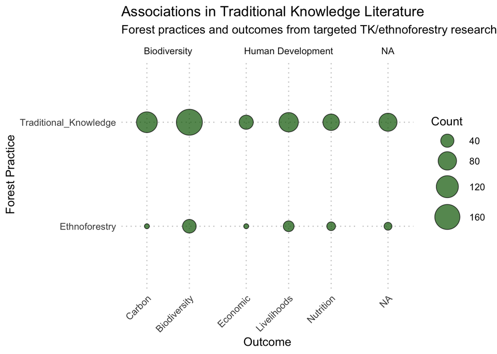

```r
# Prepare the data for plotting - using the same outcome grouping logic
tkik_association_df$OutcomeGroup <- factor(
  tkik_association_df$OutcomeGroup,
  levels = all_outcomes
)

# Add the same outcome category classification
tkik_association_df$OutcomeCategory <- ifelse(
  tkik_association_df$OutcomeGroup %in% human_development_outcomes,
  "Human Development",
  ifelse(
    tkik_association_df$OutcomeGroup %in% biodiversity_outcomes,
    "Biodiversity",
    NA
  )
)

# Create the bubble plot for TK literature
tk_association_plot <- ggplot(tkik_association_df,
                             aes(x = OutcomeGroup, y = PracticeGroup, size = Count)) +
  geom_point(shape = 21, color = "black", alpha = 0.7, fill = "darkgreen") +
  scale_size_continuous(name = "Count", range = c(2, 12)) +
  labs(
    title = "Associations in Traditional Knowledge Literature",
    subtitle = "Forest practices and outcomes from targeted TK/ethnoforestry research",
    x = "Outcome",
    y = "Forest Practice"
  ) +
  theme_minimal(base_size = 12) +
  theme(
    axis.text.x = element_text(angle = 45, hjust = 1),
    panel.grid.major = element_line(color = "gray80", linetype = "dotted"),
    panel.grid.minor = element_blank()
  ) +
  facet_grid(~ OutcomeCategory, scales = "free_x", space = "free")

tk_association_plot
```

```r
ggsave(filename = "figures/tk_association_plot.png", plot = tk_association_plot,
       width = 8, height = 5, bg = "white")
```

# References

Adin, A., J. C. Weber, C. Sotelo Montes, H. Vidaurre, B. Vosman, and M. J. M. Smulders. 2004. “Genetic Differentiation and Trade Among Populations of Peach Palm (Bactris Gasipaes Kunth) in the Peruvian Amazon - Implications for Genetic Resource Management.” *Theoretical and Applied Genetics* 108 (8): 1564–73. https://doi.org/10.1007/s00122-003-1581-9.

Adinugroho, W. C., H. L. Tata, Darwo, Y. Lisnawati, H. S. Nuroniah, R. Dewi, I. Heriansyah, and Mawazin. 2024. “Land Use Changes, Green House Gas Emissions, and Rehabilitation Model of Native Tree Species Towards Sustainable Management.” *Global Journal of Environmental Science and Management* 10 (4): 1735–58. https://doi.org/10.22034/gjesm.2024.04.15.

Adji, Beda Innocent, Xiujuan Wang, Véronique Letort, Doffou Sélastique Akaffou, Sylvie Sabatier, Mengzhen Kang, Kouadio Henri Kouassi, et al. 2024. “Stochastic Modelling of Development and Biomass Allocation: Computation Applied to Architecture of Young Mahogany Trees (Khaya Senegalensis Desr. A. Juss), a Native African Savannah Emblematic Agroforestry Species.” *Computers and Electronics in Agriculture* 220. https://doi.org/10.1016/j.compag.2024.108864.

Aerts, Raf, Kitessa Hundera, Gezahegn Berecha, Pieter Gijbels, Marieke Baeten, Maarten Van Mechelen, Martin Hermy, Bart Muys, and Olivier Honnay. 2011. “Semi-Forest Coffee Cultivation and the Conservation of Ethiopian Afromontane Rainforest Fragments.” *Forest Ecology and Management* 261 (6): 1034–41. https://doi.org/10.1016/j.foreco.2010.12.025.

Akinkuolie, Timothy A., Timothy O. Ogunbode, Aruna O. Adekiya, and Michael T. Fapohunda. 2024. “Indigenous Climate Change Mitigation Strategies in Tropical Cities – a Review.” *Frontiers in Sustainable Cities* 6. https://doi.org/10.3389/frsc.2024.1447400.

Alamgir, Mohammed, Jürgen Pretzsch, and Stephen M. Turton. 2014. “Climate Change Effects on Community Forests: Finding Through User’s Lens and Local Knowledge.” *Small-Scale Forestry* 13 (4): 445–60. https://doi.org/10.1007/s11842-014-9264-8.

Alcorn, Janis B. 1984. “Development Policy, Forests, and Peasant Farms: Reflections on Huastec-Managed Forests’ Contributions to Commercial Production and Resource Conservation.” *Economic Botany* 38 (4): 389–406. https://doi.org/10.1007/BF02859077.

Ameray, Abderrahmane, Yves Bergeron, Osvaldo Valeria, et al. 2021. “Forest Harvested Wood Products in Tropical Regions: A Meta-Analysis.” *Global Change Biology* 27 (15): 3645–59.

Aminatun, Tien, Kuswarsantyo, Suhartini, Vichit Rangpan, Zaenuddin Hudi Prasojo, and Anggun Andreyani. 2022. “Sustainable Community Forest Management in West Kalimantan: A Case Study of the Dayak Katab Kebahan Community.” *Jurnal Pengelolaan Sumberdaya Alam Dan Lingkungan* 12 (1): 158–74. https://doi.org/10.29244/jpsl.12.1.158-174.

Antonelli, Alexandre. 2023. “Indigenous Knowledge Is Key to Sustainable Food Systems.” *Nature* 613 (7943): 239–42. https://doi.org/10.1038/d41586-023-00021-4.

Appanah, S. 2013. “The Search for a Viable Silviculture in Asia’s Natural Tropical Forests.” *Unasylva* 64 (240): 35–40. https://www.scopus.com/inward/record.uri?eid=2-s2.0-84881070893&partnerID=40&md5=cee2cb98a3be453eb5e3ac8a191e2cff.

Appiah, Mark, Lawrence Damnyag, Dominic Blay, and Ari Pappinen. 2010. “Forest and Agroecosystem Fire Management in Ghana.” *Mitigation and Adaptation Strategies for Global Change* 15 (6): 551–70. https://doi.org/10.1007/s11027-010-9236-z.

Asumang-Yeboah, Doreen, Eric Mensah Kumeh, and Lawrence Kwabena Brobbey. 2022. “Community Forest Monitoring and the Social Reproduction of Inequalities in Ghana.” *Geoforum* 134: 86–95. https://doi.org/10.1016/j.geoforum.2022.06.008.

Augusseau, Xavier, Paul Nikiéma, and Emmanuel Torquebiau. 2006. “Tree Biodiversity, Land Dynamics and Farmers’ Strategies on the Agricultural Frontier of Southwestern Burkina Faso.” *Biodiversity and Conservation* 15 (2): 613–30. https://doi.org/10.1007/s10531-005-2090-8.

Backes, Martina M. 1998. “Biotic and Landscape Diversity in Autochthonous Agroforestry Systems. A Case Study from Western Kenya; [Biotische Und Landschaftliche Diversitat in Autochthonen Agroforstsystemen. Eine Fallstudie Aus Westkenia].” *Erdkunde* 52 (2): 110–26. https://doi.org/10.3112/erdkunde.1998.02.03.

———. 2001. “The Role of Indigenous Trees for the Conservation of Biocultural Diversity in Traditional Agroforestry Land Use Systems: The Bungoma Case Study: In-Situ Conservation of Indigenous Tree Species.” *Agroforestry Systems* 50 (2): 119–32. https://doi.org/10.1023/A:1010685317405.

Barba, Francisco M., and Dany Jaimovich. 2022. “Ethnic Diversity and Forest Commons.” *World Development* 158. https://doi.org/10.1016/j.worlddev.2022.105986.

Barkin, David, and Mario Fuente. 2013. “Community Forest Management: Can the Green Economy Contribute to Environmental Justice?” *Natural Resources Forum* 37 (3): 200–210. https://doi.org/10.1111/1477-8947.12010.

Barletti, Juan Pablo Sarmiento, Peter Cronkleton, and Nicole Maria Heise Vigil. 2022. “Using Q-Methodology to Bridge Different Understandings on Community Forest Management: Lessons from the Peruvian Amazon.” *Ecology and Society* 27 (4). https://doi.org/10.5751/ES-13524-270412.

Barrios, E., R. Herrera, and J. L. Valles. 1994. “Tropical Floodplain Agroforestry Systems in Mid-Orinoco River Basin, Venezuela.” *Agroforestry Systems* 28 (2): 143–57. https://doi.org/10.1007/BF00704826.

Beets, Peter N., and Graeme R. Oliver. 2007. “Water Use by Managed Stands of Pinus Radiata, Indigenous Podocarp/Hardwood Forest, and Improved Pasture in the Central North Island of New Zealand.” *New Zealand Journal of Forestry Science* 37 (2): 306–23. https://www.scopus.com/inward/record.uri?eid=2-s2.0-34547796821&partnerID=40&md5=cbc8047a88bb2d4bc436ba9a3b20caca.

Berecha, Gezahegn, Raf Aerts, Bart Muys, and Olivier Honnay. 2015. “Fragmentation and Management of Ethiopian Moist Evergreen Forest Drive Compositional Shifts of Insect Communities Visiting Wild Arabica Coffee Flowers.” *Environmental Management* 55 (2): 373–82. https://doi.org/10.1007/s00267-014-0393-9.

Beriozovas, Olegas, Dalia Perkumienė, Mindaugas Škėma, Abdellah Saoualih, Larbi Safaa, and Marius Aleinikovas. 2024. “Research Advancement in Forest Property Rights: A Thematic Review over Half a Decade Using Natural Language Processing.” *Sustainability (Switzerland)* 16 (19). https://doi.org/10.3390/su16198280.

Bhandari, Rachana, Bijay Pandeya, and Balkrishna Ghimire. 2023. “Ethnobotanical Study of Plant Resources in Dhurkot Rural Municipality, Gulmi District Nepal.” *Ethnobotany Research and Applications* 25. https://doi.org/10.32859/era.25.22.1-19.

Birhane, Emiru, Roman Teklay, Kindeya Gebrehiwet, Negasi Solomon, and Tewodros Tadesse. 2019. “Maintaining Acacia Polyacantha Trees in Farmlands Enhances Soil Fertility and Income of Farmers in North Western Tigray, Northern Ethiopia.” *Agroforestry Systems* 93 (6): 2135–49. https://doi.org/10.1007/s10457-018-0328-1.

Bishaw, Badege. 2021. “Conceptual and Practical Approaches to Integrated Watershed Management and Agroforestry to Address Food Security and Environmental Degradation in Lake Tana and the Blue Nile River Basin, Ethiopia.” *Springer Geography*, 345–61. https://doi.org/10.1007/978-3-030-76437-1_18.

Bisong, Francis E., Elizabeth E. Andrew-Essien, Adebayo I. Animashaun, and Pius B. Utang. 2009. “Indigenous Agroforestry Initiatives for Protected Area Management: A Study of ’Support Zone’ Villages of the Cross River National Park, Nigeria.” *European Journal of Scientific Research* 25 (2): 165–73. https://www.scopus.com/inward/record.uri?eid=2-s2.0-65349085193&partnerID=40&md5=7c97d55143c3eaf01d4d3f6f72144172.

Bocco, G., F. Rosete, P. Bettinger, and A. Velázquez. 2001. “Developing a GIS Program in Rural Mexico: Community Participation Equals Success.” *Journal of Forestry* 99 (6): 14–19. https://www.scopus.com/inward/record.uri?eid=2-s2.0-0035368340&partnerID=40&md5=77b3d4295a0ad7c4dfe574fe6b05622c.

Boddington, C. L., and J. C. Dodd. 2000. “The Effect of Agricultural Practices on the Development of Indigenous Arbuscular Mycorrhizal Fungi. I. Field Studies in an Indonesian Ultisol.” *Plant and Soil* 218 (1-2): 137–44. https://doi.org/10.1023/a:1014966801446.

Bonilla-Bedoya, S., L. Lugo-Salinas, A. Mora-Garcés, A. Villarreal, E. Arends, and M. Herrera. 2013. “Piaroa Shifting Cultivation: Temporal Variability of Soil Characteristics and Spatial Distribution of Crops in the Venezuelan Orinoco.” *Agroforestry Systems* 87 (5): 1189–99. https://doi.org/10.1007/s10457-013-9629-6.

Booth, C. A., M. A. Fullen, R. W. Sarsby, K. Davies, R. Kurgan, R. Bhattacharyya, J. Poesen, et al. 2007. “The BORASSUS Project: Aims, Objectives and Preliminary Insights into the Environmental and Socio-Economic Contribution of Biogeotextiles to Sustainable Development and Soil Conservation.” *WIT Transactions on Ecology and the Environment* 102: 601–10. https://doi.org/10.2495/SDP070582.

Bost, Jay. 2014. “Persea Schiedeana: A High Oil "Cinderella Species" Fruit with Potential for Tropical Agroforestry Systems.” *Sustainability (Switzerland)* 6 (1): 99–111. https://doi.org/10.3390/su6010099.

Bray, David Barton, and Alejandro Velázquez. 2009. “From Displacement-Based Conservation to Place-Based Conservation.” *Conservation and Society* 7 (1): 11–14. https://doi.org/10.4103/0972-4923.54791.

Brodt, Sonja B. 2001. “A Systems Perspective on the Conservation and Erosion of Indigenous Agricultural Knowledge in Central India.” *Human Ecology* 29 (1): 99–120. https://doi.org/10.1023/A:1007147806213.

Burkhart, Eric P., and Michael G. Jacobson. 2009. “Transitioning from Wild Collection to Forest Cultivation of Indigenous Medicinal Forest Plants in Eastern North America Is Constrained by Lack of Profitability.” *Agroforestry Systems* 76 (2): 437–53. https://doi.org/10.1007/s10457-008-9173-y.

Cadena-Zamudio, Daniel Alejandro, Pedro Cadena-Iñiguez, José Luis Arispe-Vázquez, David Heriberto Noriega-Cantú, Rocío Toledo-Aguilar, and Juan Mayo-Hernández. 2023. “ANALYSIS OF AGROFORESTRY RESEARCH IN MEXICO: A BIBLIOMETRIC APPROACH.” *Agrociencia* 57 (6): 1224–50. https://doi.org/10.47163/agrociencia.v57i6.2884.

Campbell, B. M., J. M. Clarke, and D. J. Gumbo. 1991. “Traditional Agroforestry Practices in Zimbabwe.” *Agroforestry Systems* 14 (2): 99–111. https://doi.org/10.1007/BF00045726.

Carias Vega, Dora, and Rodney J. Keenan. 2016. “Transaction Costs and the Organization of CFEs: Experiences from Ejidos in Quintana Roo, Mexico.” *Forest Policy and Economics* 70: 1–8. https://doi.org/10.1016/j.forpol.2016.05.011.

Chandler, Paul. 1994. “Adaptive Ecology of Traditionally Derived Agroforestry in China.” *Human Ecology* 22 (4): 415–42. https://doi.org/10.1007/BF02169387.

Chandler, Paul M. 1991. “The Indigenous Knowledge of Ecological Processes Among Peasants in the People’s Republic of China.” *Agriculture and Human Values* 8 (1-2): 59–66. https://doi.org/10.1007/BF01579657.

Chen, Mei-Hui, and Ying-Jen Lin. 2017. “Integrating Co-Management and the Satoyama Initiative for Forest Governance: Community-Based Ecotourism and Conservation of Adiri and Labuwan.” *Taiwan Journal of Forest Science* 32 (4): 299–316. https://www.scopus.com/inward/record.uri?eid=2-s2.0-85040064597&partnerID=40&md5=69fa6d385815e26166301f9775d5a2b9.

Chesworth, Ward. 2011. “Agrogeology.” *Encyclopedia of Earth Sciences Series* Part 4: 29–33. https://doi.org/10.1007/978-90-481-3585-1_263.

Clough, Yann, Stefan Abrahamczyk, Marc-Oliver Adams, Alam Anshary, Nunik Ariyanti, Lydia Betz, Damayanti Buchori, et al. 2010a. “Biodiversity Patterns and Trophic Interactions in Human-Dominated Tropical Landscapes in Sulawesi (Indonesia): Plants, Arthropods and Vertebrates.” *Environmental Science and Engineering (Subseries: Environmental Science)*, no. 9783642004926: 15–71. https://doi.org/10.1007/978-3-642-00493-3_2.

———, et al. 2010b. “Biodiversity Patterns and Trophic Interactions in Human-Dominated Tropical Landscapes in Sulawesi (Indonesia): Plants, Arthropods and Vertebrates.” *Environmental Science and Engineering*, 15–71. https://doi.org/10.1007/978-3-642-00493-3_2.

Cole, David M., Timothy L. White, and P. K. R. Nair. 2007. “Maintaining Genetic Resources of Peach Palm (Bactris Gasipaes Kunth): The Role of Seed Migration and Swidden-Fallow Management in Northeastern Peru.” *Genetic Resources and Crop Evolution* 54 (1): 189–204. https://doi.org/10.1007/s10722-005-3134-3.

Córdova, Raúl, Nicholas J. Hogarth, and Markku Kanninen. 2019. “Mountain Farming Systems’ Exposure and Sensitivity to Climate Change and Variability: Agroforestry and Conventional Agriculture Systems Compared in Ecuador’s Indigenous Territory of Kayambi People.” *Sustainability (Switzerland)* 11 (9). https://doi.org/10.3390/su11092623.

Cotta, Jamie N. 2017. “Revisiting Bora Fallow Agroforestry in the Peruvian Amazon: Enriching Ethnobotanical Appraisals of Non-Timber Products Through Household Income Quantification.” *Agroforestry Systems* 91 (1): 17–36. https://doi.org/10.1007/s10457-016-9892-4.

D’Amato, Anthony W., David A. Orwig, Nathan W. Siegert, Amanda Mahaffey, Les Benedict, Tyler Everett, John Daigle, Logan Johnson, Paul Catanzaro, and Caitlin Cusack. 2023. “Species Preservation in the Face of Novel Threats: Cultural, Ecological, and Operational Considerations for Preserving Tree Species in the Context of Non-Indigenous Insects and Pathogens.” *Journal of Forestry* 121 (5-6): 470–79. https://doi.org/10.1093/jofore/fvad024.

Dawson, Ian K., Barbara Vinceti, John C. Weber, Henry Neufeldt, Joanne Russell, Ard G. Lengkeek, Antoine Kalinganire, et al. 2011. “Climate Change and Tree Genetic Resource Management: Maintaining and Enhancing the Productivity and Value of Smallholder Tropical Agroforestry Landscapes. A Review.” *Agroforestry Systems* 81 (1): 67–78. https://doi.org/10.1007/s10457-010-9302-2.

De Foresta, H., and G. Michon. 1996. “The Agroforest Alternative to Imperata Grasslands: When Smallholder Agriculture and Forestry Reach Sustainability.” *Agroforestry Systems* 36 (1-3): 105–20. https://doi.org/10.1007/BF00142869.

De Jong, B. H. J. 1994. “An Outline of the Research and Education Program of CIES/Consortium.” *Agroforestry Systems* 28 (1): 85–91. https://doi.org/10.1007/BF00711992.

Dean, Erin. 2011. “Birds of One Tree: Participatory Forestry and Land Claims in Tanzania.” *Human Organization* 70 (3): 300–309. https://doi.org/10.17730/humo.70.3.7502n588hv161176.

Deb, Sourabh. 2020. “Traditional Agroforestry Systems of Northeast India.” *Environmental Science and Engineering*, 103–15. https://doi.org/10.1007/978-3-030-32463-6_5.

DeBell, Dean S. 2006. “History of Research and Attitudes about the Biology and Management of Red Alder.” *USDA Forest Service - General Technical Report PNW*, no. 669: 3–18. https://www.scopus.com/inward/record.uri?eid=2-s2.0-33746257515&partnerID=40&md5=3c50ffbb9f18314a2c7e6609d6f54ea4.

Degefu, Mekonnen Amberber, and Fantu Kifle. 2024. “Impacts of Climate Variability on the Vegetable Production of Urban Farmers in the Addis Ababa Metropolitan Area: Nexus of Climate-Smart Agricultural Technologies.” *Climate Services* 33. https://doi.org/10.1016/j.cliser.2023.100430.

Dewees, Peter A. 1995. “Trees on Farms in Malawi: Private Investment, Public Policy, and Farmer Choice.” *World Development* 23 (7): 1085–1102. https://doi.org/10.1016/0305-750X(95)00034-A.

Dhruba Bijaya, G. C., Jyoti Bhandari, Zengrang Xu, and Can Li. 2019. “Contribution of Community Forestry in Poverty Reduction: Case Study of Multiple Community Forests of Bajhang District, Nepal.” *Journal of Resources and Ecology* 10 (6): 632–40. https://doi.org/10.5814/j.issn.1674-764x.2019.06.008.

Diemont, Stewart A. W., Jessica L. Bohn, Donald D. Rayome, Sarah J. Kelsen, and Kaity Cheng. 2011. “Comparisons of Mayan Forest Management, Restoration, and Conservation.” *Forest Ecology and Management* 261 (10): 1696–1705. https://doi.org/10.1016/j.foreco.2010.11.006.

Diemont, Stewart A. W., and Jay F. Martin. 2005. “Management Impacts on the Trophic Diversity of Nematode Communities in an Indigenous Agroforestry System of Chiapas, Mexico.” *Pedobiologia* 49 (4): 325–34. https://doi.org/10.1016/j.pedobi.2005.02.003.

———. 2009. “Lacandon Maya Ecosystem Management: Sustainable Design for Subsistence and Environmental Restoration.” *Ecological Applications* 19 (1): 254–66. https://doi.org/10.1890/08-0176.1.

Dossou-Yovo, Hubert O., Valentin Kindomihou, and Brice Sinsin. 2020. “Ethnobotanical Research of Tree Species Used in Wood Carving in Southern Benin: Perspective for Sustainable Forest Conservation.” *Ethnobotany Research and Applications* 20. https://doi.org/10.32859/era.20.29.1-10.

Eisenberg, Amy, John Amato, and Dengtao. 2009. “Kam Local Indigenous Knowledge and Sustainable Resource Management in Guizhou and Guangxi Provinces.” *Ethnobotany Research and Applications* 7: 67–114. https://www.scopus.com/inward/record.uri?eid=2-s2.0-73649118846&partnerID=40&md5=db21914e8c59eeda012ac4b14101b65e.

Elfis, Prima Wahyu Titisari, Indry Chahyana, Tika Permatasari, and Norlis. 2024. “Towards Paludicultural Agroforestry: Land Use Practice Based on Malay Local Wisdom to Support Peatland Rehabilitation in Riau Province, Indonesia.” *Mires and Peat* 31. https://doi.org/10.19189/MaP.2023.OMB.Sc.2339412.

Elias, Marlène. 2013. “Influence of Agroforestry Practices on the Structure and Spatiality of Shea Trees (Vitellaria Paradoxa C.F. Gaertn.) in Central-West Burkina Faso.” *Agroforestry Systems* 87 (1): 203–16. https://doi.org/10.1007/s10457-012-9536-2.

Elias, Marlène, and Judith Carney. 2007. “African Shea Butter: A Feminized Subsidy from Nature.” *Africa* 77 (1): 37–61. https://doi.org/10.3366/afr.2007.77.1.37.

Ellis, Edward A., Angélica Navarro-Martínez, and Martha García-Ortega. 2021. “Drivers of Forest Cover Transitions in the Selva Maya, Mexico: Integrating Regional and Community Scales for Landscape Assessment.” *Land Degradation and Development* 32 (10): 3122–41. https://doi.org/10.1002/ldr.3972.

Everson, C. S., P. J. Dye, M. B. Gush, and T. M. Everson. 2011. “Water Use of Grasslands, Agroforestry Systems and Indigenous Forests.” *Water SA* 37 (5): 781–88. https://doi.org/10.4314/wsa.v37i5.15.

Falkowski, Tomasz B, Adolfo Chankin, and Stewart A. W. Diemont. 2020. “Successional Changes in Vegetation and Litter Structure in Traditional Lacandon Maya Agroforests.” *Agroecology and Sustainable Food Systems* 44 (6): 747–67. https://doi.org/10.1080/21683565.2019.1649784.

Fettig, Jacob Scott, Cahyo Prayogo, Marthen P. Sirappa, Sukiman, Burhanuddin, Sultan, and Syahrul Kurniawan. 2023. “Ethnobotany of Local Banana (Musa Spp.) Variety Loka Pere in West Sulawesi, Indonesia.” *Biodiversitas* 24 (12): 6472–83. https://doi.org/10.13057/biodiv/d241209.

Feyssa, Debela Hunde, J. T. Njoka, Z. Asfaw, and M. M. Nyangito. 2012. “Nutritional Value of Berchemia Discolor: A Potential to Food and Nutrition Security of Households.” *Journal of Biological Sciences* 12 (5): 263–71. https://doi.org/10.3923/jbs.2012.263.271.

Fitts, Lucia A., Zoila A. Cruz-Burga, and María de los Ángeles La Torre-Cuadros. 2020. “Wild Rubber Extraction in the Peruvian Amazon: Local Perception and Socioeconomic Indicators as Tools for Decisionmaking.” *Ethnobiology and Conservation* 9: 1–26. https://doi.org/10.15451/EC2020-06-9.24-1-26.

Focacci, M., P. Piussi, and G. Ciampi. 2011. “Utilization of Agricultural and Forestry Resources in Central Guatemalan Highlands: A Case Study.” *IForest* 4 (NOVEMBER): 242–47. https://doi.org/10.3832/ifor0579-004.

Food and Agriculture Organization of the United Nations. 2020. *Global Forest Resources Assessment 2020: Main Report*. Rome: FAO.

———. 2022. *The State of the World’s Forests 2022*. Rome: FAO.

———. 2024. *The State of the World’s Forests 2024*. Rome: FAO.

Forgues, Katia, Marie-Claude Carignan, Brais Marchena, Lady Mancilla, Cristian Pacheco, Elionel Pacheco Ortega, Ariosto Guainora, and Catherine Potvin. 2024. “Comparing Carbon Offsets and Livelihood Benefits in a Long-Term Reforestation Project: Agroforestry Versus Native Timber Versus Enrichment Planting.” *Ecological Solutions and Evidence* 5 (3). https://doi.org/10.1002/2688-8319.12372.

Foroughbakhch, F., L. A. Háuad, A. E. Cespedes, E. E. Ponce, and N. González. 2001. “Evaluation of 15 Indigenous and Introduced Species for Reforestation and Agroforestry in Northeastern Mexico.” *Agroforestry Systems* 51 (3): 213–21. https://doi.org/10.1023/A:1010702510914.

Friman, Jenny. 2024. “Community Forestry Management Implementation in Burkina Faso: Gendered Dynamics and Customary Complexity.” *International Journal of the Commons* 18 (1): 444–55. https://doi.org/10.5334/ijc.1259.

Fuchs, A. 1996. “Approaches to the Solution of the Conflict Between Economics and Ecology in the Tropical and Subtropical Rain-Forest as Exemplified by the Mata Atlantica of Brazil; [Losungsansatze Fur Den Konflikte Zwischen Okonomie Und Okologie Imtropischen Und Subtropischen Regenwald Am Beispiel Der Mata Atlantica Braziliens].” *Kolner Forschungen Zur Wirtschafts- Und Sozialgeographie* 45. https://www.scopus.com/inward/record.uri?eid=2-s2.0-0030390837&partnerID=40&md5=d8967c8376247e91d8663bf97cbdfb80.

Fullen, M. A., C. A. Booth, R. W. Sarsby, K. Davies, R. Kugan, R. Bhattacharyya, M. Subedi, et al. 2007. “Contributions of Biogeotextiles to Sustainable Development and Soil Conservation in Developing Countries: The BORASSUS Project.” *WIT Transactions on Ecology and the Environment* 106: 123–41. https://doi.org/10.2495/ECO070131.

Fullen, M. A., M. Subedi, C. A. Booth, R. W. Sarsby, K. Davies, R. Bhattacharyya, R. Kugan, et al. 2011. “Utilising Biological Geotextiles: Introduction to the BORASSUS Project and Global Perspectives.” *Land Degradation and Development* 22 (5): 453–62. https://doi.org/10.1002/ldr.1105.

Gall, Graham A. E., and Mary Staton. 1992. “Conclusions.” *Agriculture, Ecosystems and Environment* 42 (1-2): 217–30. https://doi.org/10.1016/0167-8809(92)90029-B.

Garcia-Fernandez, Carlos, Miguel A Casado, and Manuel Ruiz-Perez. 2008. “Agroforestry and Sustainable Resource Conservation in Haiti: A Case Study.” In *Advances in Agroforestry*, edited by Daizy R Batish and et al., 5:211–23. Springer.

Garibay-Orijel, Roberto, Juan Córdova, Joaquín Cifuentes, Ricardo Valenzuela, Arturo Estrada-Torres, and Alejandro Kong. 2009. “Integrating Wild Mushrooms Use into a Model of Sustainable Management for Indigenous Community Forests.” *Forest Ecology and Management* 258 (2): 122–31. https://doi.org/10.1016/j.foreco.2009.03.051.

Gaur, Mahesh K., and Hemlata Gaur. 2004. “Combating Desertification: Building on Traditional Knowledge Systems of the Thar Desert Communities.” *Environmental Monitoring and Assessment* 99 (1-3): 89–103. https://doi.org/10.1007/s10661-004-4005-7.

Gautam, Krishna H., and Teiji Watanabe. 2002. “Silviculture for Non-Timber Forest Product Management: Challenges and Opportunities for Sustainable Forest Management.” *Forestry Chronicle* 78 (6): 830–32. https://doi.org/10.5558/tfc78830-6.

Gebru, Belay Manjur, Sonam Wangyel Wang, Sea Jin Kim, and Woo-Kyun Lee. 2019. “Socio-Ecological Niche and Factors Affecting Agroforestry Practice Adoption in Different Agroecologies of Southern Tigray, Ethiopia.” *Sustainability (Switzerland)* 11 (13). https://doi.org/10.3390/su11133729.

German, Laura, Grace Villamor, Edgar Twine, SANDRA J. Velarde, and Berhane Kidane. 2009. “Environmental Services and the Precautionary Principle: Using Scenarios to Reconcile Conservation and Livelihood Objectives in Upper Catchments.” *Journal of Sustainable Forestry* 28 (3-5): 368–94. https://doi.org/10.1080/10549810902791515.

Ghosal, Somnath, Aloke Majumdar, and Chhanda Ruj. 2023. “Reconnecting Humans with Nature: A Nature‐based Participatory Approach for the Enhancement of Biodiversity Knowledge in Urban Area of West Bengal, India.” *GeoJournal* 88 (4): 4537–54. https://doi.org/10.1007/s10708-023-10880-z.

Gonçalves, Claudia de Brito Quadros, Madalena Maria Schlindwein, and Gabrielli Do Carmo Martinelli. 2021. “Agroforestry Systems: A Systematic Review Focusing on Traditional Indigenous Practices, Food and Nutrition Security, Economic Viability, and the Role of Women.” *Sustainability (Switzerland)* 13 (20). https://doi.org/10.3390/su132011397.

Gorel, Anaïs-Pasiphaé, Adeline Fayolle, and Jean-Louis Doucet. 2015. “Ecology and Management of the Multipurpose Erythrophleum Species (Fabaceae-Caesalpinioideae) in Africa. A Review; [Écologie Et Gestion Des Espèces Multi-Usages Du Genre Erythrophleum (Fabaceae-Caesalpinioideae) En Afrique (Synthèse Bibliographique)].” *Biotechnology, Agronomy and Society and Environment* 19 (4): 415–29. https://www.scopus.com/inward/record.uri?eid=2-s2.0-84948767028&partnerID=40&md5=b288da6ce2d1a3782bc8063d36836ade.

Götmark, Frank. 2010. “Management Alternatives for Temperate Forests with High Conservation Values in South Sweden; [Skav Skogar Med Höga Naturvärden - En Kunskapsöversikt Fri Utveckling, Traditionell Hävd Och Naturvårdsgallring - Tre Skötselalternativ För Sydsvenska Skogar].” *Svensk Botanisk Tidskrift* 104 (1 SUPPL.): S1–88. https://www.scopus.com/inward/record.uri?eid=2-s2.0-77954322451&partnerID=40&md5=3dc05fb8c0b22fcfa3fba4340604b75f.

Gouwakinnou, Gerard Nounagnon, Achille Ephrem Assogbadjo, Anne Mette Lykke, and Brice Sinsin. 2011. “Phenotypic Variations in Fruits and Selection Potential in Sclerocarya Birrea Subsp. Birrea.” *Scientia Horticulturae* 129 (4): 777–83. https://doi.org/10.1016/j.scienta.2011.05.041.

Graziosi, Ignazio, Mathias Tembo, Jean Kuate, and Alice Muchugi. 2020. “Pests and Diseases of Trees in Africa: A Growing Continental Emergency.” *Plants People Planet* 2 (1): 14–28. https://doi.org/10.1002/ppp3.31.

Gunatilleke, I. A. U. N., C. V. S. Gunatilleke, and P. Abeygunawardena. 1993. “Interdisciplinary Research Towards Management of Non-Timber Forest Resources in Lowland Rain Forests of Sri Lanka.” *Economic Botany* 47 (3): 282–90. https://doi.org/10.1007/BF02862295.

Guo, Huijun, and Christine Padoch. 1995. “Patterns and Management of Agroforestry Systems in Yunnan. An Approach to Upland Rural Development.” *Global Environmental Change* 5 (4): 273–79. https://doi.org/10.1016/0959-3780(95)00062-S.

Guodaar, Lawrence, Douglas K. Bardsley, and Jungho Suh. 2021. “Indigenous Adaptation to Climate Change Risks in Northern Ghana.” *Climatic Change* 166 (1-2). https://doi.org/10.1007/s10584-021-03128-7.

Hakim, L. 2021. “Coffee: Ethnobotany, Tourism and Biodiversity Conservation in East Java.” In *IOP Conference Series: Earth and Environmental Science*. Vol. 743. https://doi.org/10.1088/1755-1315/743/1/012063.

Hakim, Luchman, Nila Ratih Pamungkas, Karuniawan Puji Wicaksono, and Soemarno. 2018. “The Conservation of Osingnese Traditional Home Garden Agroforestry in Banyuwangi, East Java, Indonesia.” *Agrivita* 40 (3): 506–14. https://doi.org/10.17503/agrivita.v40i3.1605.

Halim, Md. Abdul, Mohammad Shaheed Hossain Chowdhury, Nur Muhammed, Mostafizur Rahman, and Masao Koike. 2008. “Sap Production from Khejur Palm (Phoenix Sylvestris Roxb) Husbandry: A Substantial Means of Seasonal Livelihood in Rural Bangladesh.” *Forests Trees and Livelihoods* 18 (3): 305–18. https://doi.org/10.1080/14728028.2008.9752638.

Hanif, Md. Abu, Ranjan Mitra Roy, Md. Shafiqul Bari, Polash Chandra Ray, Md. Shoaibur Rahman, and Md. Faruq Hasan. 2018. “Livelihood Improvements Through Agroforestry: Evidence from Northern Bangladesh.” *Small-Scale Forestry* 17 (4): 505–22. https://doi.org/10.1007/s11842-018-9400-y.

Hazarika, Animekh, Arun Jyoti Nath, Demsai Reang, Rajiv Pandey, Gudeta W. Sileshi, and Ashesh Kumar Das. 2024. “Climate Change Vulnerability and Adaptation Among Farmers Practicing Shifting Agriculture in the Indian Himalayas.” *Environmental and Sustainability Indicators* 23. https://doi.org/10.1016/j.indic.2024.100430.

He, Jun, Zhimei Zhou, Horst Weyerhaeuser, and Jianchu Xu. 2009. “Participatory Technology Development for Incorporating Non-Timber Forest Products into Forest Restoration in Yunnan, Southwest China.” *Forest Ecology and Management* 257 (10): 2010–16. https://doi.org/10.1016/j.foreco.2009.01.041.

Houédjissin, Serge S., Paulin Azokpota, Achille Assogbadjo, Corneille Ahanhanzo, and Joseph D. Hounhouigan. 2016. “Traditional Classification, Perception, and Preferences for Tallow Tree (Pentadesma Butyracea Sabine) Organs in Benin: Implications for Domestication and Conservation.” *Ethnobotany Research and Applications* 14: 491–503. https://doi.org/10.17348/era.14.0.491-503.

Hovis, Meredith, Gregory Frey, Kathleen McGinley, Frederick Cubbage, Xue Han, and Megan Lupek. 2022. “Ownership, Governance, Uses, and Ecosystem Services of Community Forests in the Eastern United States.” *Forests* 13 (10). https://doi.org/10.3390/f13101577.

Huang, Ji, and Chunlin Long. 2007. “Coptis Teeta-Based Agroforestry System and Its Conservation Potential: A Case Study from Northwest Yunnan.” *Ambio* 36 (4): 343–49. https://doi.org/10.1579/0044-7447(2007)36[343:CTASAI]2.0.CO;2.

Hudson, Alex, William Milliken, Jonathan Timberlake, Peter Giovannini, Valdemar Fijamo, Joao Massunde, Hercilia Chipanga, Milagre Nivunga, and Tiziana Ulian. 2020. “Natural Plant Resources for Sustainable Development: Insights from Community Use in the Chimanimani Trans-Frontier Conservation Area, Mozambique.” *Human Ecology* 48 (1): 55–67. https://doi.org/10.1007/s10745-020-00132-w.

Imoro, Ziblim Abukari, Abubakari Zarouk Imoro, Abudu Ballu Duwiejuah, and Ammal Abukari. 2021. “Harnessing Indigenous Technologies for Sustainable Management of Land, Water, and Food Resources Amidst Climate Change.” *Frontiers in Sustainable Food Systems* 5. https://doi.org/10.3389/fsufs.2021.691603.

Jacobi, Johanna, Sarah-Lan Mathez-Stiefel, Helen Gambon, Stephan Rist, and Miguel Altieri. 2017. “Whose Knowledge, Whose Development? Use and Role of Local and External Knowledge in Agroforestry Projects in Bolivia.” *Environmental Management* 59 (3): 464–76. https://doi.org/10.1007/s00267-016-0805-0.

Jama, B. A., A. M. Mohamed, J. Mulatya, and A. N. Njui. 2008. “Comparing the "Big Five": A Framework for the Sustainable Management of Indigenous Fruit Trees in the Drylands of East and Central Africa.” *Ecological Indicators* 8 (2): 170–79. https://doi.org/10.1016/j.ecolind.2006.11.009.

Jegora, Tefera, Zebene Asfaw, and Agena Anjulo. 2019. “Woody Species Diversity and Management in Homegarden Agroforestry: The Case of Shashemene District, Ethiopia.” *International Journal of Forestry Research* 2019. https://doi.org/10.1155/2019/3697047.

Jepsen, Thea, Gaia Stopponi, and Niels O. G. Jørgensen. 2024. “Shea Tree (Vitellaria Paradoxa C.F. Gaertn.) Agroforestry Systems in Northern Ghana: Population Structure, Management of Trees and Impact of Below Canopy Microclimate.” *Agroforestry Systems* 98 (6): 1493–1506. https://doi.org/10.1007/s10457-024-01019-1.

Jones, Mitchell, and et al. 2020. “A Review of Mycelium Composites as a Sustainable Alternative to Conventional Materials.” *Sustainability* 12 (24): 10273.

Jumiyati, Sri, and Evi Frimawaty. 2024. “APPLICATION OF EDU-AGROTOURISM AND AGROFORESTRY: PATTERNS OF LAND USE ON CONSERVATION IN THE BUFFER AREA.” *International Journal of Conservation Science* 15 (1): 657–72. https://doi.org/10.36868/IJCS.2024.01.19.

Jusu, Amadu, and Aida Cuni-Sanchez. 2017. “Priority Indigenous Fruit Trees in the African Rainforest Zone: Insights from Sierra Leone.” *Genetic Resources and Crop Evolution* 64 (4): 745–60. https://doi.org/10.1007/s10722-016-0397-9.

Kala, C. P. 2010. “Status of an Indigenous Agro-Forestry System in Changing Climate: A Case Study of the Middle Himalayan Region of Tehri Garhwal, India.” *Journal of Forest Science* 56 (8): 373–80. https://doi.org/10.17221/113/2009-jfs.

Kanmegne, J., L. A. Bayomock, B. Duguma, and D. O. Ladipo. 2000. “Screening of 18 Agroforestry Species for Highly Acid and Aluminum Toxic Soils of the Humid Tropics.” *Agroforestry Systems* 49 (1): 31–39. https://doi.org/10.1023/A:1006334931018.

Keller, Nadine, Pascal A. Niklaus, Jaboury Ghazoul, Tobias Marfil, Elia Godoong, and Christopher D. Philipson. 2023. “Biodiversity Consequences of Long-Term Active Forest Restoration in Selectively-Logged Tropical Rainforests.” *Forest Ecology and Management* 549. https://doi.org/10.1016/j.foreco.2023.121414.

Kellner, Kenneth F., Patrick J. Ruhl, John B. Dunning, Jeffery K. Riegel, and Robert K. Swihart. 2016. “Multi-Scale Responses of Breeding Birds to Experimental Forest Management in Indiana, USA.” *Forest Ecology and Management* 382: 64–75. https://doi.org/10.1016/j.foreco.2016.10.008.

Kendrick, Sarah W., Paul A. Porneluzi, Frank R. Thompson Iii, Dana L. Morris, Janet M. Haslerig, and John Faaborg. 2015. “Stand-Level Bird Response to Experimental Forest Management in the Missouri Ozarks.” *Journal of Wildlife Management* 79 (1): 50–59. https://doi.org/10.1002/jwmg.804.

Kimaro, Oforo Didas, Ellen Desie, Bruno Verbist, Didas Nahum Kimaro, Karen Vancampenhout, and Karl-Heinz Feger. 2024. “Soil Organic Carbon Stocks and Fertility in Smallholder Indigenous Agroforestry Systems of the North-Eastern Mountains, Tanzania.” *Geoderma Regional* 36. https://doi.org/10.1016/j.geodrs.2024.e00759.

Kiptot, Evelyne, and Steven Franzel. 2012. “Gender and Agroforestry in Africa: A Review of Women’s Participation.” *Agroforestry Systems* 84 (1): 35–58. https://doi.org/10.1007/s10457-011-9419-y.

Kujawska, Monika, and Lukasz Luczaj. 2015. “The Use of Woody Plants in Local Communities: A Case Study in Central Ukraine.” *Human Ecology* 43: 655–66.

Kumar, Anil, S. Hashmi, A. Shukla, and O. P. Chaturvedi. 2007. “Effect of Intercropping on Inoculum Potential of Arbuscular Mycorrhizal Fungi in Agroforestry Systems.” *Annals of Arid Zone* 46 (1): 31–36. https://www.scopus.com/inward/record.uri?eid=2-s2.0-46449098560&partnerID=40&md5=328d1a18c87fa50c71541f914639a82b.

Langston, James D., Rebecca A. Riggs, Yazid Sururi, Terry Sunderland, and Muhammad Munawir. 2017. “Estate Crops More Attractive Than Community Forests in West Kalimantan, Indonesia.” *Land* 6 (1). https://doi.org/10.3390/land6010012.

Larsen, David R., and Paul S. Johnson. 1998. “Linking the Ecology of Natural Oak Regeneration to Silviculture.” *Forest Ecology and Management* 106 (1): 1–7. https://doi.org/10.1016/S0378-1127(97)00233-8.

Leakey, R. R. B. 2001. “Win: Win Landuse Strategies for Africa: 2. Capturing Economic and Environmental Benefits with Multistrata Agroforests.” *International Forestry Review* 3 (1): 11–18. https://www.scopus.com/inward/record.uri?eid=2-s2.0-0035093264&partnerID=40&md5=f98b87e1f7dd676951cd89d704e3465c.

Lelamo, Latamo Lameso. 2021. “A Review on the Indigenous Multipurpose Agroforestry Tree Species in Ethiopia: Management, Their Productive and Service Roles and Constraints.” *Heliyon* 7 (9). https://doi.org/10.1016/j.heliyon.2021.e07874.

Lestari, Sri, and Bondan Winarno. 2023. “Understanding Indigenous Knowledge in Sustainable Management of NTFPs Agroforestry in Indonesia: A Case of Southern Sumatra.” In *IOP Conference Series: Earth and Environmental Science*. Vol. 1133. https://doi.org/10.1088/1755-1315/1133/1/012063.

Lintangah, W. J., V. Atin, A. L. Ibrahim, H. Yahya, E. B. Johnlee, R. A. Martin, and G. John. 2022. “Sustainable Forest Management Contribution to Food Security: A Stakeholders’ Perspectives in Sabah, Malaysia.” In *IOP Conference Series: Earth and Environmental Science*. Vol. 1053. https://doi.org/10.1088/1755-1315/1053/1/012012.

Lokonon, Bruno E., Essomanda Tchandao Mangamana, Isidore Gnonlonfoun, Téwogbadé Jean Didier Akpona, Achille E. Assogbadjo, Romain Glèlè Kakaï, and Brice Sinsin. 2019. “Knowledge, Valuation and Prioritization of 46 Woody Species for Conservation in Agroforestry Systems Along Ouémé Catchment in Benin (West Africa).” *Environment, Development and Sustainability* 21 (5): 2377–99. https://doi.org/10.1007/s10668-018-0142-y.

Lombardero, María J., Marta Alonso-Rodríguez, and Eva P. Roca-Posada. 2012. “Tree Insects and Pathogens Display Opposite Tendencies to Attack Native Vs. Non-Native Pines.” *Forest Ecology and Management* 281: 121–29. https://doi.org/10.1016/j.foreco.2012.06.036.

Lompo, Djingdia, Barbara Vinceti, Heino Konrad, Jérôme Duminil, and Thomas Geburek. 2020. “Fine-Scale Spatial Genetic Structure, Mating, and Gene Dispersal Patterns in Parkia Biglobosa Populations with Different Levels of Habitat Fragmentation.” *Applications in Plant Sciences* 107 (7): 1041–53. https://doi.org/10.1002/ajb2.1504.

Londres, Marina, Mark Schulze, Christina L. Staudhammer, and Karen A. Kainer. 2017. “Population Structure and Fruit Production of Carapa Guianensis (Andiroba) in Amazonian Floodplain Forests: Implications for Community-Based Management.” *Tropical Conservation Science* 10. https://doi.org/10.1177/1940082917718835.

Long, Alan J., and P. K. Ramachandran Nair. 1999. “Trees Outside Forests: Agro-, Community, and Urban Forestry.” *New Forests* 17 (1-3): 145–74. https://doi.org/10.1023/a:1006523425548.

Maconachie, Roy, Adamu Tanko, and Mustapha Zakariya. 2009. “Descending the Energy Ladder? Oil Price Shocks and Domestic Fuel Choices in Kano, Nigeria.” *Land Use Policy* 26 (4): 1090–99. https://doi.org/10.1016/j.landusepol.2009.01.008.

Madge, C. 1995. “Ethnography and Agroforestry Research: A Case Study from the Gambia.” *Agroforestry Systems* 32 (2): 127–46. https://doi.org/10.1007/BF00711569.

Maezumi, S. Yoshi, Daiana Alves, Mark Robinson, Jonas Gregorio de Souza, Carolina Levis, Robert L. Barnett, Edemar Almeida de Oliveira, Dunia Urrego, Denise Schaan, and José Iriarte. 2018. “The Legacy of 4,500 Years of Polyculture Agroforestry in the Eastern Amazon.” *Nature Plants* 4 (8): 540–47. https://doi.org/10.1038/s41477-018-0205-y.

Magura, Tibor, Dávid Bogyó, Szabolcs Mizser, Dávid D. Nagy, and Béla Tóthmérész. 2015. “Recovery of Ground-Dwelling Assemblages During Reforestation with Native Oak Depends on the Mobility and Feeding Habits of the Species.” *Forest Ecology and Management* 339: 117–26. https://doi.org/10.1016/j.foreco.2014.12.015.

Mandila, Brexidis, and Timothy Namaswa. 2022. “Ethnobotany of Pokot Communities on Bamboo Species in the Dryland Areas of West Pokot County, Kenya.” *Journal of Bamboo and Rattan* 21 (3): 86–102. https://doi.org/10.55899/09734449/jbr021301.

Manginsela, Elsje Pauline, Oktavianus Porajouw, Martha Mareyke Sendow, Aprilia Deasi Wehantow, Olivia Bulanta, Christian Mewengkang, and Oschard Pariakhan. 2021. “The Role of Women in Managing Sustainable Forestry Based on Local Authority and Needs Analysis of the Local Agroforestry System in North Sulawesi.” In *IOP Conference Series: Earth and Environmental Science*. Vol. 763. https://doi.org/10.1088/1755-1315/763/1/012070.

Maranz, Steven. 2009. “Tree Mortality in the African Sahel Indicates an Anthropogenic Ecosystem Displaced by Climate Change.” *Journal of Biogeography* 36 (6): 1181–93. https://doi.org/10.1111/j.1365-2699.2008.02081.x.

Maraseni, T. N., P. R. Neupane, F. Lopez-Casero, and T. Cadman. 2014. “An Assessment of the Impacts of the REDD+ Pilot Project on Community Forests User Groups (CFUGs) and Their Community Forests in Nepal.” *Journal of Environmental Management* 136: 37–46. https://doi.org/10.1016/j.jenvman.2014.01.011.

Marie, Chloé N., Nicole Sibelet, Michel Dulcire, Minah Rafalimaro, Pascal Danthu, and Stéphanie M. Carrière. 2009. “Taking into Account Local Practices and Indigenous Knowledge in an Emergency Conservation Context in Madagascar.” *Biodiversity and Conservation* 18 (10): 2759–77. https://doi.org/10.1007/s10531-009-9672-9.

Mariel, Juliette, Vincent Freycon, Josoa Randriamalala, Verohanitra Rafidison, and Vanesse Labeyrie. 2022. “Local Knowledge of the Interactions Between Agrobiodiversity and Soil: A Fertile Substrate for Adapting to Changes in the Soil in Madagascar?” *Journal of Ethnobiology* 42 (2): 180–97. https://doi.org/10.2993/0278-0771-42.2.180.

Marshall, Craig, Samuel K. Riffell, Darren A. Miller, JoVonn G. Hill, Kristine O. Evans, and Scott A. Rush. 2017. “Bird Response to Intercropping Switchgrass Within a Loblolly Pine Plantation.” *Wildlife Society Bulletin* 41 (4): 659–65. https://doi.org/10.1002/wsb.839.

Martini, E., J. M. Roshetko, P. Purnomosidhi, J. Tarigan, N. Idris, and T. Zulfadhli. 2013. “Fruit Germplasm Resources and Demands for Small Scale Farmers Post-Tsunami and Conflicts in Nanggroe Aceh Darussalam Province, Indonesia.” *Acta Horticulturae* 975: 657–64. https://doi.org/10.17660/ActaHortic.2013.975.82.

Mason, Stephen C., Korodjouma Ouattara, Sibiri Jean-Baptiste Taonda, Siébou Palé, Adama Sohoro, and Daniel Kaboré. 2015. “Soil and Cropping System Research in Semi-Arid West Africa as Related to the Potential for Conservation Agriculture.” *International Journal of Agricultural Sustainability* 13 (2): 120–34. https://doi.org/10.1080/14735903.2014.945319.

Mathez-Stiefel, Sarah-Lan, Jorge Ayquipa-Valenzuela, Ruben Corrales-Quispe, Luzmila Rosales-Richard, and Merelyn Valdivia-Díaz. 2016. “Identifying Gender-Sensitive Agroforestry Options: Methodological Considerations from the Field.” *Mountain Research and Development* 36 (4): 417–30. https://doi.org/10.1659/MRD-JOURNAL-D-16-00051.1.

Mbile, P., Z. Tchoundjeu, E. Asaah, A. Degrande, P. Anegbeh, C. C. Facheux, M. L. Mpeck, D. Foundjem-Tita, and C. Mbosso. 2006. “Rural Livelihoods: Conservation, Management and Use of Plant Biodiversity in West and Central Africa.” *Biodiversity* 7 (3-4): 17–26. https://doi.org/10.1080/14888386.2006.9712807.

McDonald, M. A., A. Hofny-Collins, J. R. Healey, and T. C. R. Goodland. 2003. “Evaluation of Trees Indigenous to the Montane Forest of the Blue Mountains, Jamaica for Reforestation and Agroforestry.” *Forest Ecology and Management* 175 (1-3): 379–401. https://doi.org/10.1016/S0378-1127(02)00132-9.

Meinhold, Kathrin, and Dietrich Darr. 2021. “Using a Multi-Stakeholder Approach to Increase Value for Traditional Agroforestry Systems: The Case of Baobab (Adansonia Digitata L.) in Kilifi, Kenya.” *Agroforestry Systems* 95 (7): 1343–58. https://doi.org/10.1007/s10457-020-00562-x.

Méndez-López, María Elena, Eduardo García-Frapolli, Diana J. Pritchard, María Consuelo Sánchez González, Isabel Ruiz-Mallén, Luciana Porter-Bolland, and Victoria Reyes-Garcia. 2014. “Local Participation in Biodiversity Conservation Initiatives: A Comparative Analysis of Different Models in South East Mexico.” *Journal of Environmental Management* 145: 321–29. https://doi.org/10.1016/j.jenvman.2014.06.028.

Mesa, Laura, and Gloria Galeano. 2013. “Palms Uses in the Colombian Amazon; [Usos de Las Palmas En La Amazonia Colombiana].” *Caldasia* 35 (2): 351–69. https://www.scopus.com/inward/record.uri?eid=2-s2.0-84890826787&partnerID=40&md5=ba0bd5dbf6af48233e75fa11f0c4ea10.

Meunier, Quentin, Sylvie Boldrini, Carl Moumbogou, Amélie Morin, Sostène Ibinga, and Cédric Vermeulen. 2014. “The Coexistence of Traditional Slash-and-Burn Farming and Community Forests in Gabon; [Place de l’agriculture Itinérante Familiale Dans La Foresterie Communautaire Au Gabon].” *Bois Et Forets Des Tropiques* 68 (319): 65–69. https://doi.org/10.19182/bft2014.319.a20553.

Mganga, K. Z., N. K. R. Musimba, and D. M. Nyariki. 2015. “Combining Sustainable Land Management Technologies to Combat Land Degradation and Improve Rural Livelihoods in Semi-Arid Lands in Kenya.” *Environmental Management* 56 (6): 1538–48. https://doi.org/10.1007/s00267-015-0579-9.

Mganga, Kevin Z. 2023. “Agricultural Land Degradation in Kenya.” *Handbook of Environmental Chemistry* 120: 273–300. https://doi.org/10.1007/698_2022_929.

Michon, Geneviève. 2005. “Domesticating Forests: How Farmers Manage Forest Resources.” *Ecology and Society* 10 (1): 1.

Middendorp, Romaike S., Veerle Vanacker, and Eric F. Lambin. 2018. “Impacts of Shaded Agroforestry Management on Carbon Sequestration, Biodiversity and Farmers Income in Cocoa Production Landscapes.” *Landscape Ecology* 33 (11): 1953–74. https://doi.org/10.1007/s10980-018-0714-0.

Miehe, S. 1986. “Acacia Albida and Other Multipurpose Trees on the Fur Farmlands in the Jebel Marra Highlands, Western Darfur, Sudan.” *Agroforestry Systems* 4 (2): 89–119. https://doi.org/10.1007/BF00141543.

Miller, Robert Pritchard, and P. K. R. Nair. 2006. “Indigenous Agroforestry Systems in Amazonia: From Prehistory to Today.” *Agroforestry Systems* 66 (2): 151–64. https://doi.org/10.1007/s10457-005-6074-1.

Mishra, P. K., and S. C. Rai. 2013. “Use of Indigenous Soil and Water Conservation Practices Among Farmers in Sikkim Himalaya.” *Indian Journal of Traditional Knowledge* 12 (3): 454–64. https://www.scopus.com/inward/record.uri?eid=2-s2.0-84879750146&partnerID=40&md5=ac94c63b6fce5225099b5079c095719a.

Montagnini, F., A. Fanzeres, and S. G. Da Vinha. 1995. “The Potentials of 20 Indigenous Tree Species for Soil Rehabilitation in the Atlantic Forest Region of Bahia, Brazil.” *Journal of Applied Ecology* 32 (4): 841–56. https://doi.org/10.2307/2404824.

Montagnini, Florencia, Beatriz I. Eibl, and Sara R. Barth. 2011. “ORGANIC YERBA MATE: AN ENVIRONMENTALLY, SOCIALLY AND FINANCIALLY SUITABLE AGROFORESTRY SYSTEM; [YERBA MATÉ BIOLOGIQUE: UN SYSTÈME AGROFORESTIER EN PHASE AVEC L’ENVIRONNEMENT ET L’éCONOMIE SOCIALE ET FINANCIÈRE]; [YERBA MATE ORGÁNICA: UN SISTEMA AGROFORESTAL AMBIENTAL, SOCIAL Y FINANCIERAMENTE ADECUADO].” *Bois Et Forets Des Tropiques* 308: 59–74. https://doi.org/10.19182/bft2011.308.a20475.

Moore, Jonathan Harry, Saifon Sittimongkol, Ahimsa Campos-Arceiz, Tok Sumpah, and Markus Peter Eichhorn. 2016. “Fruit Gardens Enhance Mammal Diversity and Biomass in a Southeast Asian Rainforest.” *Biological Conservation* 194: 132–38. https://doi.org/10.1016/j.biocon.2015.12.015.

Moreno-Calles, Ana Isabel, Alejandro Casas, Alexis Daniela Rivero-Romero, Yessica Angélica Romero-Bautista, Selene Rangel-Landa, Roberto Alexander Fisher-Ortíz, Fernando Alvarado-Ramos, Mariana Vallejo-Ramos, and Dídac Santos-Fita. 2016. “Ethnoagroforestry: Integration of Biocultural Diversity for Food Sovereignty in Mexico.” *Journal of Ethnobiology and Ethnomedicine* 12 (1). https://doi.org/10.1186/s13002-016-0127-6.

Morris, Dana L., Paul. A. Porneluzi, Janet Haslerig, Richard L. Clawson, and John Faaborg. 2013. “Results of 20 Years of Experimental Forest Management on Breeding Birds in Ozark Forests of Missouri, USA.” *Forest Ecology and Management* 310: 747–60. https://doi.org/10.1016/j.foreco.2013.09.020.

Morris, Geoff, and Phan Sy Hieu. 2008. “Factors Affecting the Sustainable Development of Community-Managed Nurseries for Promoting Rare Conifer Species in North-West Vietnam.” *Small-Scale Forestry* 7 (3-4): 369–86. https://doi.org/10.1007/s11842-008-9060-4.

Muhesi, Eloge Kambale, Jean Lagarde Betti, Ndongo Din, Moïse Musubao Kapiri, Harmelle Natacha Nana Afiong, and Pascal Billong Fils. 2023. “Ethnobotanical Knowledge of Prunus Africana (Hook. F.) Kalkman (Rosaceae) by People Living in Community Forests in North Kivu, Eastern Democratic Republic of Congo.” *Ethnobotany Research and Applications* 26. https://doi.org/10.32859/era.26.12.1-28.

Mulyoutami, Elok, Ratna Rismawan, and Laxman Joshi. 2009. “Local Knowledge and Management of Simpukng (Forest Gardens) Among the Dayak People in East Kalimantan, Indonesia.” *Forest Ecology and Management* 257 (10): 2054–61. https://doi.org/10.1016/j.foreco.2009.01.042.

Munoz, Samuel E., David J. Mladenoff, Sissel Schroeder, and John W. Williams. 2014. “Defining the Spatial Patterns of Historical Land Use Associated with the Indigenous Societies of Eastern North America.” *Journal of Biogeography* 41 (12): 2195–2210. https://doi.org/10.1111/jbi.12386.

Nahuelhual, Laura, Juana Palma, Mauro E. Gonzalez, and Karin Ortiz. 2008. “Potential for Greenery from Degraded Temperate Forests to Increase Income of Indigenous Women in Chile.” *Agroforestry Systems* 74 (1): 97–109. https://doi.org/10.1007/s10457-008-9151-4.

Nair, P. K. R. 1999. “Agroforestry Research at a Crossroads.” *Annals of Arid Zone* 38 (3-4): 415–30. https://www.scopus.com/inward/record.uri?eid=2-s2.0-0033258882&partnerID=40&md5=a616be32ff1ef3b1686a7e6f36062bf5.

Nandigama, Sailaja. 2020. “Performance of Success and Failure in Grassroots Conservation and Development Interventions: Gender Dynamics in Participatory Forest Management in India.” *Land Use Policy* 97. https://doi.org/10.1016/j.landusepol.2018.05.061.

Narendra, Budi H., James M. Roshetko, Hesti L. Tata, and Elok Mulyoutami. 2013. “Prioritizing Underutilized Tree Species for Domestication in Smallholder Systems of West Java.” *Small-Scale Forestry* 12 (4): 519–38. https://doi.org/10.1007/s11842-012-9227-x.

Nath, Arun Jyoti, Rattan Lal, and Ashesh Kumar Das. 2015. “Ethnopedology and Soil Properties in Bamboo (Bambusa Sp.) Based Agroforestry System in North East India.” *Catena* 135: 92–99. https://doi.org/10.1016/j.catena.2015.07.001.

Negash, Mesele, Mike Starr, Markku Kanninen, and Leakemaraiam Berhe. 2013. “Allometric Equations for Estimating Aboveground Biomass of Coffea Arabica L. Grown in the Rift Valley Escarpment of Ethiopia.” *Agroforestry Systems* 87 (4): 953–66. https://doi.org/10.1007/s10457-013-9611-3.

Negash, Mesele, Eshetu Yirdaw, and Olavi Luukkanen. 2012. “Potential of Indigenous Multistrata Agroforests for Maintaining Native Floristic Diversity in the South-Eastern Rift Valley Escarpment, Ethiopia.” *Agroforestry Systems* 85 (1): 9–28. https://doi.org/10.1007/s10457-011-9408-1.

Neves, Eduardo G., and Michael J. Heckenberger. 2019. “The Call of the Wild: Rethinking Food Production in Ancient Amazonia.” *Annual Review of Anthropology* 48: 371–88. https://doi.org/10.1146/annurev-Anthro-102218-011057.

Ngulube, Mzoma R., John B. Hall, and J. A. Maghembe. 1996. “A Review of the Silviculture and Resource Potential of Amiombo Fruittree: Uapaca Kirkiana (Euphorbiaceae).” *Journal of Tropical Forest Science* 8 (3): 395–411. https://www.scopus.com/inward/record.uri?eid=2-s2.0-0346259497&partnerID=40&md5=10921ab838485a2246d9bc3800dcb4dd.

Nietzel, Olaf, and et al. 2022. “Life Cycle Assessment of Agricultural Fiber Composites for Construction Applications.” *Journal of Cleaner Production* 380: 134884.

Nischalke, Sarah Marie, Mulunesh Abebe, Beneberu Assefa Wondimagegnhu, Simone Kathrin Kriesemer, and Tina Beuchelt. 2017. “Forgotten Forests? Food Potential of Ancient Coffee Forests and Agroforestry Systems in the Southwestern Ethiopian Mountains, Seen Through a Gender Lens.” *Mountain Research and Development* 37 (3): 254–62. https://doi.org/10.1659/MRD-JOURNAL-D-16-00096.1.

Njurumana, G. N., D. Octavia, O. Hidayat, T. Basuki, and Y. Ngongo. 2024. “The Resilience of Indigenous Natural Resources Management Amidst Covid-19 Pandemic in East Nusa Tenggara, Indonesia.” In *AIP Conference Proceedings*. Vol. 3001. https://doi.org/10.1063/5.0183962.

Njurumana, Gerson N., Ronggo Sadono, Djoko Marsono, and Irham. 2021. “Ecosystem Services of Indigenous Kaliwu Agroforestry System in Sumba, Indonesia.” In *E3S Web of Conferences*. Vol. 305. https://doi.org/10.1051/e3sconf/202130504002.

Obiri, John, Michael Lawes, and Michael Mukolwe. 2002. “The Dynamics and Sustainable Use of High-Value Tree Species of the Coastal Pondoland Forests of the Eastern Cape Province, South Africa.” *Forest Ecology and Management* 166 (1-3): 131–48. https://doi.org/10.1016/S0378-1127(01)00665-X.

Obunga, Gilbay, Mika Siljander, Marianne Maghenda, and P. K. E. Pellikka. 2022. “Habitat Suitability Modelling to Improve Conservation Status of Two Critically Endangered Endemic Afromontane Forest Bird Species in Taita Hills, Kenya.” *Journal for Nature Conservation* 65. https://doi.org/10.1016/j.jnc.2021.126111.

Ofori, D. A., and J. R. Cobbinah. 2007. “Integrated Approach for Conservation and Management of Genetic Resources of Milicia Species in West Africa.” *Forest Ecology and Management* 238 (1-3): 1–6. https://doi.org/10.1016/j.foreco.2006.09.091.

Okello, Cornelius, Yvonne Wambui Githiora, Simangele Sithole, and Margaret Awuor Owuor. 2024. “Nature-Based Solutions for Water Resource Management in Africa’s Arid and Sem-Arid Lands (ASALs): A Systematic Review of Existing Interventions.” *Nature-Based Solutions* 6. https://doi.org/10.1016/j.nbsj.2024.100172.

Ołdak, A. 1992. “Geographical Information System Techniques in Land Use Assessment Within Landscape Types in Eastern Poland.” *Land Degradation & Development* 3 (3): 181–94. https://doi.org/10.1002/ldr.3400030307.

Orozco-Quintero, Alejandra, and Fikret Berkes. 2010. “Role of Linkages and Diversity of Partnerships in a Mexican Community-Based Forest Enterprise.” *Journal of Enterprising Communities* 4 (2): 148–61. https://doi.org/10.1108/17506201011048059.

Ortega-Álvarez, Rubén, Alana Pacheco-Flores, and Alejandro Casas. 2022. “The ‘Guamúchil’ Cultivation in a Mexican Cultural Landscape: A Wild Food Source for People and Birds.” *Frontiers in Forests and Global Change* 5. https://doi.org/10.3389/ffgc.2022.1020207.

Ortega-Álvarez, Rubén, Viviana Ruiz-Gutiérrez, Orin J. Robinson, Esteban Berrones Benítez, Israel Medina Mena, and J. Jaime Zúñiga-Vega. 2021. “Beyond Incidence Data: Assessing Bird Habitat Use in Indigenous Working Landscapes Through the Analysis of Behavioral Variation Among Land Uses.” *Landscape and Urban Planning* 211. https://doi.org/10.1016/j.landurbplan.2021.104100.

Osorno-Covarrubias, F. J., S. Couturier, and M. Piceno Hernández. 2018. “Measuring from Space the Efficiency of Local Forest Management: The Successful Case of the Indigenous Community of Cherán, Mexico.” In *IOP Conference Series: Earth and Environmental Science*. Vol. 151. https://doi.org/10.1088/1755-1315/151/1/012010.

Otuoma, John, Beatrice Anyango, George Ouma, David Okeyo, Gabriel M. Muturi, and Boniface Oindo. 2016. “Determinants of Aboveground Carbon Offset Additionality in Plantation Forests in a Moist Tropical Forest in Western Kenya.” *Forest Ecology and Management* 365: 61–68. https://doi.org/10.1016/j.foreco.2016.01.028.

Panda, Smita Mishra. 1999. “Towards a Sustainable Natural Resource Management of Tribal Communities: Findings from a Study of Swidden and Wetland Cultivation in Remote Hill Regions of Eastern India.” *Environmental Management* 23 (2): 205–16. https://doi.org/10.1007/s002679900180.

Pandey, D. K., P. Adhiguru, H. K. De, A. D. Upadhyay, and K. Radhakrishnan. 2021. “Income Inequality Among Indigenous People Dependent on Traditional Agroforestry System in Indian Himalayas.” *Indian Journal of Agricultural Sciences* 91 (6): 847–51. https://www.scopus.com/inward/record.uri?eid=2-s2.0-85131624658&partnerID=40&md5=4452b699e5d64014055caf9435ec1db8.

Pandey, Deep Narayan. 2002a. “Carbon Sequestration in Agroforestry Systems.” *Climate Policy* 2 (4): 367–77. https://doi.org/10.1016/S1469-3062(02)00025-6.

———. 2002b. “Carbon Sequestration in Agroforestry Systems.” *Climate Policy* 2 (4): 367–77. https://doi.org/10.3763/cpol.2002.0240.

———. 2007. “Multifunctional Agroforestry Systems in India.” *Current Science* 92 (4): 455–63. https://www.scopus.com/inward/record.uri?eid=2-s2.0-33947125099&partnerID=40&md5=be7dbd01ee22e0bb1749174a055936b6.

Pangapanga-Phiri, Innocent, Eric Dada Mungatana, Lucy Pangapanga, and Francis Samson Nkoka. 2022. “Understanding the Impact of Sustainable Land-Scape Management Practices on Farm Productivity Under Intensifying Tropical Cyclones: Evidence from Southern Malawi.” *Tropical Cyclone Research and Review* 11 (4): 265–76. https://doi.org/10.1016/j.tcrr.2023.02.002.

Papu, Sapna, and Nishant Nathani. 2020. “India,s First Green Village —,Khonoma,” *International Journal of Environmental Science and Development* 11 (1): 21–25. https://doi.org/10.18178/ijesd.2020.11.1.1220.

Parikesit, K. Takeuchi, A. Tsunekawa, and O. S. Abdoellah. 2005. “Kebon Tatangkalan: A Disappearing Agroforest in the Upper Citarum Watershed, West Java, Indonesia.” *Agroforestry Systems* 63 (2): 171–82. https://doi.org/10.1007/s10457-004-1182-x.

Paterson, R. T., G. M. Karanja, R. L. Roothaert, O. Z. Nyaata, and I. W. Kariuki. 1998. “A Review of Tree Fodder Production and Utilization Within Smallholder Agroforestry Systems in Kenya.” *Agroforestry Systems* 41 (2): 181–99. https://doi.org/10.1023/A:1006066128640.

Paudel, Krishna Chandra, Karl Pieber, Raphael-Thomas Klumpp, and Margit Laimer De Camara Machado. 2003. “Evaluation of Lapsi Tree (Choerospondias Axillaris, Roxb.) for Fruit Production in Nepal.” *Bodenkultur* 54 (1): 3–9. https://www.scopus.com/inward/record.uri?eid=2-s2.0-0042850363&partnerID=40&md5=9fe3bcbb41808d2b76029a28db648c6c.

Paudel, Shankar, and K. Freerk Wiersum. 2002. “Tenure Arrangements and Management Intensity of Butter Tree (Diploknema Butyracea) in Makawanpur District, Nepal.” *International Forestry Review* 4 (3): 223–30. https://doi.org/10.1505/IFOR.4.3.223.17394.

Peng, Yougui, Zhengchun Xu, and Minchao Liu. 2012. “Introduction and Ecological Effects of an Exotic Mangrove Species Sonneratia Apetala.” *Shengtai Xuebao/ Acta Ecologica Sinica* 32 (7): 2259–70. https://doi.org/10.5846/stxb201110161530.

Phondani, P. C., R. K. Maikhuri, L. S. Rawat, A. Jugran, A. Bhatt, and N. S. Bisht. 2017. “Policy Implications of Utilizing Indigenous Tree Species as Agroforestry Systems in Himalayan States of India: Case Study of Uttarakhand.” *Energy Policy* 110: 202–9. https://doi.org/10.1016/j.enpol.2017.08.022.

Piabuo, Serge Mandiefe, Divine Foundjem-Tita, and Peter A. Minang. 2018. “Community Forest Governance in Cameroon: A Review.” *Ecology and Society* 23 (3). https://doi.org/10.5751/ES-10330-230334.

Piabuo, Serge Mandiefe, Marjanke Hoogstra-Klein, Verina Ingram, and Divine Foundjem-Tita. 2022. “Community Forest Enterprises (CFEs) as Social Enterprises: Empirical Evidence from Cameroon.” *Forest Policy and Economics* 135. https://doi.org/10.1016/j.forpol.2021.102664.

Pinheiro, Felipe M., and P. K. Ramachandran Nair. 2018. “Silvopasture in the Caatinga Biome of Brazil: A Review of Its Ecology, Management, and Development Opportunities.” *Forest Systems* 27 (1). https://doi.org/10.5424/fs/2018271-12267.

Pinho, Rachel C., Robert P. Miller, and Sonia S. Alfaia. 2012. “Agroforestry and the Improvement of Soil Fertility: A View from Amazonia.” *Applied and Environmental Soil Science* 2012. https://doi.org/10.1155/2012/616383.

Poudyal, Bishnu Hari, Tek Maraseni, Geoff Cockfield, and Bhola Bhattarai. 2020. “Recognition of Historical Contribution of Indigenous Peoples and Local Communities Through Benefit Sharing Plans (BSPs) in REDD+.” *Environmental Science and Policy* 106: 111–14. https://doi.org/10.1016/j.envsci.2020.01.022.

Pröpper, Michael, and Bjørn Vollan. 2013. “Beyond Awareness and Self-Governance: Approaching Kavango Timber Users’ Real-Life Choices.” *Land* 2 (3): 392–418. https://doi.org/10.3390/land2030392.

Rai, Prabhat Kumar. 2012. “Assessment of Multifaceted Environmental Issues and Model Development of an Indo-Burma Hotspot Region.” *Environmental Monitoring and Assessment* 184 (1): 113–31. https://doi.org/10.1007/s10661-011-1951-8.

Rai, Prabhat Kumar, and Jamuna S. Singh. 2024. “Ecological Insights and Environmental Threats of Invasive Alien Plant Chromolaena Odorata: Prospects for Sustainable Management.” *Weed Biology and Management* 24 (1): 15–37. https://doi.org/10.1111/wbm.12286.

Rai, Prabhat Kumar, and Vanlalruati. 2022. “Societal Perception on Environmental and Socio-Economic Implications of Tithonia Diversifolia (Hemsl.) A. Gray Invasion in an Indo-Burma Biodiversity Hotspot.” *Environmental and Socio-Economic Studies* 10 (3): 59–66. https://doi.org/10.2478/environ-2022-0017.

Rajasekaran, B., D. M. Warren, and S. C. Babu. 1991. “Indigenous Natural‐resource Management Systems for Sustainable Agricultural Development—a Global Perspective.” *Journal of International Development* 3 (3): 387–401. https://doi.org/10.1002/jid.4010030312.

Rassing, A. R. T., A. Gunawan, and P. I. Pratiwi. 2024. “Agricultural Landscape Model Based on the Culture of the Indigenous People of Tana Toraja, South Sulawesi.” In *IOP Conference Series: Earth and Environmental Science*. Vol. 1384. https://doi.org/10.1088/1755-1315/1384/1/012022.

Rastogi, Sonali, Ritu Verma, Rajapandi Raju, Venkateshan Narayanan, Pooja Anand Mundada, Rakhee Maheshwari, Yuvraj Pandhare, and Ruchi Tiwari. 2024. “Unveiling the Therapeutic Potential and Conservation Strategies for Rare and Endangered Medicinal Plants in Traditional Chinese Medicine: A Comprehensive Review.” *Zhongguo Ying Yong Sheng Li Xue Za Zhi = Zhongguo Yingyong Shenglixue Zazhi = Chinese Journal of Applied Physiology* 40: e20240024. https://doi.org/10.62958/j.cjap.2024.024.

Reang, Demsai, Animekh Hazarika, Gudeta Weldesemayat Sileshi, Arun Jyoti Nath, Venkatesh Paramesh, W. Reshmi Singha, and Ashesh Kumar Das. 2024. “Piper Agroforestry in the Indian Himalayas: Indigenous Peoples’ Practices, Policies and Incentives.” *CABI Agriculture and Bioscience* 5 (1). https://doi.org/10.1186/s43170-024-00214-5.

Reang, Demsai, Animekh Hazarika, Gudeta W. Sileshi, Rajiv Pandey, Ashesh Kumar Das, and Arun Jyoti Nath. 2021. “Assessing Tree Diversity and Carbon Storage During Land Use Transitioning from Shifting Cultivation to Indigenous Agroforestry Systems: Implications for REDD+ Initiatives.” *Journal of Environmental Management* 298. https://doi.org/10.1016/j.jenvman.2021.113470.

Reang, Demsai, Arun Jyoti Nath, Gudeta Weldesemayat Sileshi, Animekh Hazarika, and Ashesh Kumar Das. 2022. “Post-Fire Restoration of Land Under Shifting Cultivation: A Case Study of Pineapple Agroforestry in the Sub-Himalayan Region.” *Journal of Environmental Management* 305. https://doi.org/10.1016/j.jenvman.2021.114372.

Reyes-García, Victoria, Unai Pascual, Vincent Vadez, and Tomás Huanca. 2011. “The Role of Ethnobotanical Skills and Agricultural Labor in Forest Clearance: Evidence from the Bolivian Amazon.” *Ambio* 40 (3): 310–21. https://doi.org/10.1007/s13280-010-0107-3.

Rideng, I Wayan, I Nyoman Putu Budiartha, and Ketut Adi Wirawan. 2021. “DECONSTRUCTION ORIENTATION OF VILLAGE FOREST UTILIZATION POLICY.” *Journal of Legal, Ethical and Regulatory Issues* 24 (7): 1–9. https://www.scopus.com/inward/record.uri?eid=2-s2.0-85112654401&partnerID=40&md5=146099d97433fd2ad346670dc121eb81.

Robinson, Ewan. 2021. “Citizens, Custodians, and Villains: Environmentality and the Politics of Difference in Senegal’s Community Forests.” *Geoforum* 125: 25–36. https://doi.org/10.1016/j.geoforum.2021.06.017.

Robles-Diaz-De-Leon, L. F., and P. Kangas. 1998. “Evaluation of Potential Gross Income from Non-Timber Products in a Model Riparian Forest for the Chesapeake Bay Watershed.” *Agroforestry Systems* 44 (2-3): 215–25. https://doi.org/10.1023/a:1006246510419.

Rodan, Bruce D., Adrian C. Newton, and Adalberto Verissimo. 1992. “Mahogany Conservation: Status and Policy Initiatives.” *Environmental Conservation* 19 (4): 331–38. https://doi.org/10.1017/S0376892900031453.

Rodrigues, D. L., and R. Lok. 2000. “Improving Egg Production in Two Indigenous Communities Through the Adaptation of Management Practices and Local Knowledge: The Results of Participation Research.” *Annals of the New York Academy of Sciences* 916: 662–64. https://doi.org/10.1111/j.1749-6632.2000.tb05356.x.

Roshetko, J. M., P. Purnomosidhi, G. Sabastian, L. Dahlia, M. Mahrizal, E. Mulyoutami, A. Perdana, et al. 2017. “Ethnobotanical Use and Commercial Potential of Moringa Oleifera in Indonesia: An Underused and Under-Recognized Species.” *Acta Horticulturae* 1158: 349–56. https://doi.org/10.17660/ActaHortic.2017.1158.39.

Ruiz-Mallen, Isabel, and Laura Barraza. 2008. “Are Adolescents from a Forest Community Well-Informed about Forest Management?” *Journal of Biological Education* 42 (3): 104–11. https://doi.org/10.1080/00219266.2008.9656122.

Sahide, Muhammad Alif K., Dodik Ridho Nurrochmat, and Lukas Giessen. 2015. “The Regime Complex for Tropical Rainforest Transformation: Analysing the Relevance of Multiple Global and Regional Land Use Regimes in Indonesia.” *Land Use Policy* 47: 408–25. https://doi.org/10.1016/j.landusepol.2015.04.030.

Sanchez, Pedro A. 1999. “Delivering on the Promise of Agroforestry.” *Environment, Development and Sustainability* 1 (3-4): 275–84. https://doi.org/10.1023/a:1010083007121.

Sardeshpande, Mallika, and Charlie Shackleton. 2019. “Wild Edible Fruits: A Systematic Review of an Under-Researched Multifunctional NTFP (Non-Timber Forest Product).” *Forests* 10 (6). https://doi.org/10.3390/f10060467.

Schönafinger, Alexander, Lukas Egarter Vigl, and Erich Tasser. 2024. “Spatiotemporal Patterns and Drivers of Orchard Meadow Loss in South Tyrol, Italy.” *Scientific Reports* 14 (1). https://doi.org/10.1038/s41598-024-81077-8.

Schulze, E. D., G. Aas, G. W. Grimm, M. M. Gossner, H. Walentowski, C. Ammer, I. Kühn, O. Bouriaud, and K. von Gadow. 2016. “A Review on Plant Diversity and Forest Management of European Beech Forests.” *European Journal of Forest Research* 135 (1): 51–67. https://doi.org/10.1007/s10342-015-0922-y.

Scudder, Micah G., John Herbohn, and Jack Baynes. 2019. “Are Portable Sawmills a Financially Viable Option for Economic Development in Tropical Forests?” *Forest Policy and Economics* 100: 188–97. https://doi.org/10.1016/j.forpol.2018.12.011.

Seid, Hadia, Emiru Birhane, Fassil Kebede, Kiros Meles Hadgu, Aklilu Negussie, and Lindsey Norgrove. 2016. “Response of Selected Indigenous Dryland Agroforestry Tree Species to Salinity and Implications for Soil Fertility Management.” *Agroforestry Systems* 90 (6): 1133–42. https://doi.org/10.1007/s10457-016-9891-5.

Serrano-Rojas, Shirley J., Andrew Whitworth, Julio A. Paredes-Garcia, Ruthmery Pillco-Huarcaya, Lawrence Whittaker, Karl H. Huaypar-Loayza, and Ross MacLeod. 2022. “Indigenous Lands Are Better for Amphibian Biodiversity Conservation Than Immigrant-Managed Agricultural Lands: A Case Study From Manu Biosphere Reserve, Peru.” *Tropical Conservation Science* 15. https://doi.org/10.1177/19400829221134811.

Sharma, Archana. 2012. “Scientific Harvesting for Quality Seed Collection of Buchanania Lanzan Spreng for Its Conservation and Sustainable Management - Case Study of Chhindwara, Madhya Pradesh, India.” *International Journal of Bio-Science and Bio-Technology* 4 (1): 65–74. https://www.scopus.com/inward/record.uri?eid=2-s2.0-84859302436&partnerID=40&md5=de0a44863cd1ec6e32ec68f6cd14cdfc.

Sharma, Kishor, Bhoj Kumar Acharya, Ghanashyam Sharma, Donatella Valente, Maria Rita Pasimeni, Irene Petrosillo, and Thiru Selvan. 2020. “Land Use Effect on Butterfly Alpha and Beta Diversity in the Eastern Himalaya, India.” *Ecological Indicators* 110. https://doi.org/10.1016/j.ecolind.2019.105605.

Shi, Peili, and Wenhua Li. 1999. “Rehabilitation of Degraded Mountain Ecosystems in Southwestern China: An Integrated Approach.” *Ambio* 28 (5): 390–97. https://www.scopus.com/inward/record.uri?eid=2-s2.0-0032827511&partnerID=40&md5=cb89a332ffbe042a868fd22227582ca8.

Shinbrot, Xoco A., Ignacia Holmes, Madeleine Gauthier, Petra Tschakert, Zoë Wilkins, Lydia Baragón, Berta Opúa, and Catherine Potvin. 2022. “Natural and Financial Impacts of Payments for Forest Carbon Offset: A 14 Year-Long Case Study in an Indigenous Community in Panama.” *Land Use Policy* 115. https://doi.org/10.1016/j.landusepol.2022.106047.

Shukla, Gopal, Ashok Kumar, Nazir A. Pala, and Sumit Chakravarty. 2016. “Farmers Perception and Awareness of Climate Change: A Case Study from Kanchandzonga Biosphere Reserve, India.” *Environment, Development and Sustainability* 18 (4): 1167–76. https://doi.org/10.1007/s10668-015-9694-2.

Shumba, E. M., C. T. Marunda, I. B. Nyoka, and D. Maruzane. 1998. “Setting Research Priorities for Indigenous and Social Forestry in Zimbabwe.” *Southern African Forestry Journal* 181 (1): 39–43. https://doi.org/10.1080/10295925.1998.9631179.

Sileshi, Gudeta Weldesemayat, Elias Kuntashula, Patrick Matakala, and Philip O. Nkunika. 2008. “Farmers’ Perceptions of Tree Mortality, Pests and Pest Management Practices in Agroforestry in Malawi, Mozambique and Zambia.” *Agroforestry Systems* 72 (2): 87–101. https://doi.org/10.1007/s10457-007-9082-5.

Sileshi, Gudeta W., Philip Nyeko, Phillip O. Y. Nkunika, Benjamin M. Sekematte, Festus K. Akinnifesi, and Oluyede C. Ajayi. 2009. “Integrating Ethno-Ecological and Scientific Knowledge of Termites for Sustainable Termite Management and Human Welfare in Africa.” *Ecology and Society* 14 (1). https://doi.org/10.5751/ES-02877-140148.

Silva Junior, Celso H. L., Danielle Celentano, Guillaume X. Rousseau, Emanoel Gomes de Moura, István van Deursen Varga, Carlos Martinez, and Marlúcia B. Martins. 2020. “Amazon Forest on the Edge of Collapse in the Maranhão State, Brazil.” *Land Use Policy* 97. https://doi.org/10.1016/j.landusepol.2020.104806.

Silva-Galicia, Ana, John Larsen, Ricardo Álvarez-Espino, and Eliane Ceccon. 2023. “Agroecological and Agroforestry Strategies to Improve Organic Hibiscus Productivity in an Indigenous Non-Governmental Organization from Mexico.” *Renewable Agriculture and Food Systems* 38. https://doi.org/10.1017/S1742170522000369.

Singh, Arun P., R. S. Bhandari, and T. D. Verma. 2004. “Important Insect Pests of Poplars in Agroforestry and Strategies for Their Management in Northwestern India.” *Agroforestry Systems* 63 (1): 15–26. https://doi.org/10.1023/B:AGFO.0000049429.37483.47.

Singh, Naresh, Manoj Kumar Riyal, Bhupendra Singh, Vinod Prasad Khanduri, Deepa Rawat, Chandramohan Singh, Marina M. S. Cabral Pinto, and Munesh Kumar. 2024. “Carbon Sequestration Potential of Agroforestry Versus Adjoining Forests at Different Altitudes in the Garhwal Himalayas.” *Atmosphere* 15 (3). https://doi.org/10.3390/atmos15030313.

Singh, Ranjay K., Shah M. Hussain, T. Riba, Anshuman Singh, Egul Padung, Orik Rallen, Y. J. Lego, and Ajay Kumar Bhardwaj. 2018. “Classification and Management of Community Forests in Indian Eastern Himalayas: Implications on Ecosystem Services, Conservation and Livelihoods.” *Ecological Processes* 7 (1). https://doi.org/10.1186/s13717-018-0137-5.

Smith, Nigel J. H. 2001. “Land Use Dynamics in the Amazon Estuary and Implications for Natural Resource Management.” *Amazoniana* 16 (3-4): 517–37. https://www.scopus.com/inward/record.uri?eid=2-s2.0-0009999988&partnerID=40&md5=03352257e216e2e78ddaa49881008458.

Sonwa, D. J., J. C. Okafor, P. Mpungi Buyungu, S. F. Weise, M. Tchatat, A. A. Adesina, A. B. Nkongmeneck, O. Ndoye, and D. Endamana. 2002. “Dacryodes Edulis, a Neglected Non-Timber Forest Species for the Agroforestry Systems of West and Central Africa.” *Forests Trees and Livelihoods* 12 (1-2): 41–55. https://doi.org/10.1080/14728028.2002.9752409.

Souza, Saulo E. X. Franco de, Edson Vidal, Germano de Freitas Chagas, Amelia T. Elgar, and Pedro H. S. Brancalion. 2016. “Ecological Outcomes and Livelihood Benefits of Community-Managed Agroforests and Second Growth Forests in Southeast Brazil.” *Biotropica* 48 (6): 868–81. https://doi.org/10.1111/btp.12388.

Stahl, Peter W. 2015. “Interpreting Interfluvial Landscape Transformations in the Pre-Columbian Amazon.” *Holocene* 25 (10): 1598–1603. https://doi.org/10.1177/0959683615588372.

Stancheva, Jordanka, Sonja Bencheva, Krasimira Petkova, and Vladimir Piralkov. 2007. “Possibilities for Agroforestry Development in Bulgaria: Outlooks and Limitations.” *Ecological Engineering* 29 (4): 382–87. https://doi.org/10.1016/j.ecoleng.2006.09.013.

Stanly, Shimly, N. Rasana, S. Rajendrakumar, and K. Nithya. 2024. “Eco-Centric Approaches: Integrating Indigenous Agricultural Wisdom and Practices in Realizing the Sustainable Development Agendas.” *Water, Air, and Soil Pollution* 235 (11). https://doi.org/10.1007/s11270-024-07525-3.

Steward, Gregory A., and Anthony E. Beveridge. 2010. “A Review of New Zealand Kauri (Agathis Australis (D.Don) Lindl.): Its Ecology, History, Growth and Potential for Management for Timber.” *New Zealand Journal of Forestry Science* 40: 33–59. https://www.scopus.com/inward/record.uri?eid=2-s2.0-77649325459&partnerID=40&md5=eb743e1cb0ef1aef6733eb15856c4aba.

Suffice, Pauline, Hugo Asselin, Louis Imbeau, Marianne Cheveau, and Pierre Drapeau. 2017. “More Fishers and Fewer Martens Due to Cumulative Effects of Forest Management and Climate Change as Evidenced from Local Knowledge.” *Journal of Ethnobiology and Ethnomedicine* 13 (1). https://doi.org/10.1186/s13002-017-0180-9.

Sunmonu, T. O., and J. Van Staden. 2014. “Phytotoxicity Evaluation of Six Fast-Growing Tree Species in South Africa.” *South African Journal of Botany* 90: 101–6. https://doi.org/10.1016/j.sajb.2013.10.010.

Svenning, Jens-Christian, and Manuel J. Macía. 2002. “Harvesting of Geonoma Macrostachys Mart. Leaves for Thatch: An Exploration of Sustainability.” *Forest Ecology and Management* 167 (1-3): 251–62. https://doi.org/10.1016/S0378-1127(01)00699-5.

Tadesse, Eguale, Abdu Abdulkedir, Asia Khamzina, Yowhan Son, and Florent Noulèkoun. 2019. “Contrasting Species Diversity and Values in Home Gardens and Traditional Parkland Agroforestry Systems in Ethiopian Sub-Humid Lowlands.” *Forests* 10 (3). https://doi.org/10.3390/f10030266.

Teklay, Tesfay. 2007. “Decomposition and Nutrient Release from Pruning Residues of Two Indigenous Agroforestry Species During the Wet and Dry Seasons.” *Nutrient Cycling in Agroecosystems* 77 (2): 115–26. https://doi.org/10.1007/s10705-006-9048-4.

Teklehaimanot, Z. 2004. “Exploiting the Potential of Indigenous Agroforestry Trees: Parkia Biglobosa and Vitellaria Paradoxa in Sub-Saharan Africa.” *Agroforestry Systems* 61-62 (1-3): 207–20. https://doi.org/10.1023/B:AGFO.0000029000.22293.d1.

Tenagyei, Louis, and Issaka Kanton Osumanu. 2021. “Farmers’ Perceived Effectiveness of Indigenous Land Management Practices: A Study in Semi-Arid Ghana.” *Local Environment* 26 (12): 1532–45. https://doi.org/10.1080/13549839.2021.1994534.

Thijs, Koen W., Raf Aerts, Pieter van de Moortele, Job Aben, Winfred Musila, Petri Pellikka, Hubert Gulinck, and Bart Muys. 2015. “Trees in a Human-Modified Tropical Landscape: Species and Trait Composition and Potential Ecosystem Services.” *Landscape and Urban Planning* 144: 49–58. https://doi.org/10.1016/j.landurbplan.2015.07.015.

Thomas, Frank M., Andreas Rzepecki, and Willy Werner. 2022. “Non-Native Douglas Fir (Pseudotsuga Menziesii) in Central Europe: Ecology, Performance and Nature Conservation.” *Forest Ecology and Management* 506. https://doi.org/10.1016/j.foreco.2021.119956.

Timsina, Shrabya, Lila Nath Sharma, Mark S Ashton, Bishnu Hari Poudyal, Ian K Nuberg, Srijana Baral, Edwin Cedamon, Sanjeeb Bir Bajracharya, and Naya Sharma Paudel. 2022. “Lessons from Managing for the Extremes: A Case for Decentralized, Adaptive, Multipurpose Forest Management Within an Ecological Framework.” *Forests* 13 (2). https://doi.org/10.3390/f13020333.

Tomar, J. M. S., Anup Das, and A. Arunachalam. 2013. “Crop Response and Soil Fertility as Influenced by Green Leaves of Indigenous Agroforestry Tree Species in a Lowland Rice System in Northeast India.” *Agroforestry Systems* 87 (1): 193–201. https://doi.org/10.1007/s10457-012-9535-3.

Tougiani, Abasse, Chaibou Guero, and Tony Rinaudo. 2009. “Community Mobilisation for Improved Livelihoods Through Tree Crop Management in Niger.” *GeoJournal* 74 (5): 377–89. https://doi.org/10.1007/s10708-008-9228-7.

Tsvetkov, V. F., and A. N. Brovina. 2017. “Challenges of Forestry in Subarctic European Russia.” *Russian Journal of Forest Science*, no. 4: 284–92. https://doi.org/10.7868/S0024114817040040.

Twedt, Daniel J., R. Randy Wilson, Jackie L. Henne-Kerr, and Robert B. Hamilton. 1999. “Impact of Forest Type and Management Strategy on Avian Densities in the Mississippi Alluvial Valley, USA.” *Forest Ecology and Management* 123 (2-3): 261–74. https://doi.org/10.1016/S0378-1127(99)00043-2.

Urruth, Leonardo Marques, Joana Braun Bassi, and Davi Chemello. 2022. “Policies to Encourage Agroforestry in the Southern Atlantic Forest.” *Land Use Policy* 112. https://doi.org/10.1016/j.landusepol.2021.105802.

Van Gils, Hein, Joseph Delfino, Denis Rugege, and Lynda Janssen. 2004. “Efficacy of Chromolaena Odorata Control in a South African Conservation Forest.” *South African Journal of Science* 100 (5-6): 251–53. https://www.scopus.com/inward/record.uri?eid=2-s2.0-4344717993&partnerID=40&md5=980e2152d04e0ee8bc8d94850213ad76.

Van Itterbeeck, Joost, Niane Sivongxay, Bounthob Praxaysombath, and Arnold Van Huis. 2014. “Indigenous Knowledge of the Edible Weaver Ant Oecophylla Smaragdina Fabricius Hymenoptera: Formicidae from the Vientiane Plain, Lao PDR.” *Ethnobiology Letters* 5 (1): 4–12. https://doi.org/10.14237/ebl.5.2014.125.

Venkateswarlu, B. 2012. “Dryland Agriculture: Coping with Climate Change.” *Annals of Arid Zone* 51 (3-4): 171–80. https://www.scopus.com/inward/record.uri?eid=2-s2.0-84928472055&partnerID=40&md5=03e5ab5182bc50940c271a0140898816.

Ventura-Aquino, Yalina, Beatriz Rendón, Silvia Rebollar, and Gilberto Hernández. 2008. “Use and Conservation of Forest Resources in the Municipality of San Agustin Loxicha, Sierra Madre Del Sur, Oaxaca, Mexico.” *Agroforestry Systems* 73 (3): 167–80. https://doi.org/10.1007/s10457-008-9107-8.

Vera, Roy R., J. Hugo Cota-Sánchez, and Jorge E Grijalva Olmedo. 2017. “Biodiversity, Dynamics, and Impact of Chakras on the Ecuadorian Amazon.” *Journal of Plant Ecology* 12 (1): 34–44. https://doi.org/10.1093/jpe/rtx060.

Vié, Jean-Christophe, Craig Hilton-Taylor, and Simon N. Stuart. 2009. “The IUCN Red List: A Key Conservation Tool.” *Wildlife in a Changing World–An Analysis of the 2008 IUCN Red List of Threatened Species*, 1–14.

Vihotogbé, Romaric, Romain Glèlè Kakaï, Frans Bongers, Tinde Van Andel, Ronald G. Van Den Berg, Brice Sinsin, and Marc S. M. Sosef. 2014. “Impacts of the Diversity of Traditional Uses and Potential Economic Value on Food Tree Species Conservation Status: Case Study of African Bush Mango Trees (Irvingiaceae) in the Dahomey Gap (West Africa).” *Plant Ecology and Evolution* 147 (1): 109–25. https://doi.org/10.5091/plecevo.2014.789.

Villa, Pedro Manuel, Sebastião Venâncio Martins, Silvio Nolasco de Oliveira Neto, Alice Cristina Rodrigues, Enrique Pino Hernández, and Dong-Gill Kim. 2020. “Policy Forum: Shifting Cultivation and Agroforestry in the Amazon: Premises for REDD+.” *Forest Policy and Economics* 118. https://doi.org/10.1016/j.forpol.2020.102217.

Villa, Pedro Manuel, Sebastião Venâncio Martins, Silvio Nolasco de Oliveira Neto, Alice Cristina Rodrigues, Lucieta Guerreiro Martorano, Luisa Delgado Monsanto, Norman Mota Cancio, and Markus Gastauer. 2018. “Intensification of Shifting Cultivation Reduces Forest Resilience in the Northern Amazon.” *Forest Ecology and Management* 430: 312–20. https://doi.org/10.1016/j.foreco.2018.08.014.

Viswanath, S., P. K. R. Nair, P. K. Kaushik, and U. Prakasam. 2000. “Acacia Nilotica Trees in Rice Fields: A Traditional Agroforestry System in Central India.” *Agroforestry Systems* 50 (2): 157–77. https://doi.org/10.1023/A:1006486912126.

Vyamana, Vincent G., Shabani A. O. Chamshama, and Samora M. Andrew. 2021. “Soil Nutrients and Maize Yields Responses to Indigenous Agroforestry Tree Post-Fallows Management in Tanzania.” *Trees, Forests and People* 6. https://doi.org/10.1016/j.tfp.2021.100164.

Wall, Jeffrey, Coşkun Köse, Nesibe Köse, Taner Okan, Elif Başak Aksoy, Devra Jarvis, and Shorna Allred. 2019. “The Role of Traditional Livelihood Practices and Local Ethnobotanical Knowledge in Mitigating Chestnut Disease and Pest Severity in Turkey.” *Forests* 10 (7). https://doi.org/10.3390/f10070571.

Wang, Hui, Shi-Rong Liu, Jiang-Ming Mo, Jing-Xin Wang, Franz Makeschin, and Maria Wolff. 2010. “Soil Organic Carbon Stock and Chemical Composition in Four Plantations of Indigenous Tree Species in Subtropical China.” *Ecological Research* 25 (6): 1071–79. https://doi.org/10.1007/s11284-010-0730-2.

Wang, Jian-jun, and Jing-hui Meng. 2018. “Identifying Indigenous Tree Species for Land Reforestation, Forest Restoration, and Plantation Transformation on Hainan Island, China.” *Journal of Mountain Science* 15 (11): 2433–44. https://doi.org/10.1007/s11629-018-4861-1.

Wartman, P. C., K. E. Dunfield, K. Khosla, C. Loucks, R. C. Van Acker, and R. C. Martin. 2017. “The Establishment of Apple Orchards as Temperate Forest Garden Systems and Their Impact on Indigenous Bacterial and Fungal Population Abundance in Southern Ontario, Canada.” *Renewable Agriculture and Food Systems* 32 (2): 157–68. https://doi.org/10.1017/S1742170516000120.

Webb, Edward L., and M. Khurshid. 2000. “Divergent Destinies Among Pine Forests in Northern Pakistan: Linking Ecosystem Characteristics with Community Self-Governance and Local Institutions.” *International Journal of Sustainable Development and World Ecology* 7 (3): 189–200. https://doi.org/10.1080/13504500009470040.

Wiersum, K. F. 1997. “From Natural Forest to Tree Crops, Co-Domestication of Forests and Tree Species, an Overview.” *Netherlands Journal of Agricultural Science* 45 (4): 425–38. https://www.scopus.com/inward/record.uri?eid=2-s2.0-0031350110&partnerID=40&md5=5cf0c8282c74ea31a3706408a6ca5a21.

Wilkinson, Kim M. 2009. “Agroforestry Systems and Podocarpus National Park, Ecuador: Current Status and Recommendations for Future Work.” *Journal of Sustainable Forestry* 28 (6-7): 844–65. https://doi.org/10.1080/10549810902936631.

Willis, K. J., L. Gillson, and T. M. Brncic. 2004. “How "Virgin" Is Virgin Rainforest?” *Science* 304 (5669): 402–3.

Xiu, Yu, Guo-Dong Wu, De-Zhong Chen, Xiao-Qing Zhao, Wen-Si Tang, and Hua-Fang Wang. 2017. “Propagation and Afforestation Techniques of Tree Peonies for Greening and Seed Oil Production.” *Beijing Linye Daxue Xuebao/Journal of Beijing Forestry University* 39 (1): 112–18. https://doi.org/10.13332/j.1000-1522.20160045.

Yanchun, Guo. 1998. “The Thought and Techniques in the Preservation of the Environment: The Case of Tai Ethnic Group in Xishuangbanna, Yunnan.” *Southeast Asian Studies (Kyoto)* 35 (3): 465–88. https://www.scopus.com/inward/record.uri?eid=2-s2.0-0031848701&partnerID=40&md5=8ace7b48dffda1c196ee1aa68de6cc5f.

Yu, Han-Ming, Fu-Ching Ma, Yen-Ray Hsu, Nai-Hang Chang, and Fu-Wen Horng. 2008. “Silvicultural Growth Performances of Thirteen Endemic Broadleaf Trees of Taiwan.” *Taiwan Journal of Forest Science* 23 (3): 255–70. https://www.scopus.com/inward/record.uri?eid=2-s2.0-52249094447&partnerID=40&md5=5102839540d123d1fb144f16d69e217e.

Zebrowski, Wesley M., and Travis W. Reynolds. 2024. “Consumed from Within? Social and Ecological Drivers of Internal Clearings in Ethiopian Orthodox Church Forests.” *Land Degradation and Development* 35 (1): 334–49. https://doi.org/10.1002/ldr.4919.

Zenda, Mashford, and Michael Rudolph. 2024. “A Systematic Review of Agroecology Strategies for Adapting to Climate Change Impacts on Smallholder Crop Farmers’ Livelihoods in South Africa.” *Climate* 12 (3). https://doi.org/10.3390/cli12030033.

Zerbo, Issouf, Kolawolé Valère Salako, Achille Hounkpèvi, Djirensolo Zozoda, Romain Glèlè Kakaï, and Adjima Thiombiano. 2022. “Ethnobotanical Knowledge and Conservation of Bombax Costatum Pellegr. And Vuillet: An Overexploited Savanna Tree Species.” *Trees, Forests and People* 10. https://doi.org/10.1016/j.tfp.2022.100356.

Zou, Lü-Liu, Zhi-Ling Dao, and Chun-Lin Long. 2009. “Study on Community Forest Resource Management of the Zhuang Nationality in Southeast Yunnan of China.” *Journal of Plant Resources and Environment* 18 (1): 67–73. https://www.scopus.com/inward/record.uri?eid=2-s2.0-65249150084&partnerID=40&md5=32cf43bf62dd10300a516fd32b0eb6ea.

Zoysa, Mangala De. 2022. “Forest-Based Ecotourism in Sri Lanka: A Review on State of Governance, Livelihoods, and Forest Conservation Outcomes.” *Journal of Sustainable Forestry* 41 (3-5): 413–39. https://doi.org/10.1080/10549811.2021.1943450.